# Effectiveness of European Regional Development Funds in reducing unemployment: a temporal analysis

This document contains the code used for the empirical analysis conducted in my final thesis for the Master in Computational Social Sciences.

# Libraries

```r
rm(list = ls())
library(tidyverse)
library(readxl)
library(DataExplorer)
library(ARDECO)
library(slider)
library(modelsummary)
library(mice)
library(eurostat)
library(sf)
library(cowplot)
library(grid)
library(gt)
```

# Preparing the dataset

## ERDF expenditure data

Source: [Cohesion Open Data Platform](https://cohesiondata.ec.europa.eu/Other/Historic-EU-payments-annual-timeseries-regionalise/tc55-7ysv/about_data)

### Loading data

```r
funds <- read_csv("data/funds.csv")

funds <- funds |>
  # Selecting only ERDF data
  filter(Fund == "ERDF") |>
  # Selecting only relevant variables
  select(Country, NUTS2_ID, NUTS2_name, Year,
         Programming_Period, Modelled_annual_expenditure) |>
  rename(Budget_Cycle = Programming_Period,
         Expenditure = Modelled_annual_expenditure)
head(funds)
```

```
## # A tibble: 6 × 6
##   Country NUTS2_ID NUTS2_name                      Year Budget_Cycle Expenditure
##   <chr>   <chr>    <chr>                          <dbl> <chr>              <dbl>
## 1 BE      BE10     Région de Bruxelles-Capitale …  1990 1989-1993           3253
## 2 BE      BE10     Région de Bruxelles-Capitale …  1991 1989-1993          31593
## 3 BE      BE10     Région de Bruxelles-Capitale …  1992 1989-1993          23647
## 4 BE      BE10     Région de Bruxelles-Capitale …  1993 1989-1993           9622
## 5 BE      BE10     Région de Bruxelles-Capitale …  1994 1989-1993          18910
## 6 BE      BE10     Région de Bruxelles-Capitale …  1995 1989-1993          13264
```

As per source this expenditure data uses NUTS 2013 codes

### Cleaning

```r
funds <- funds |>
  # Pivoting wider to obtain 1 column per budget period
  pivot_wider(names_from = Budget_Cycle, values_from = Expenditure,
              names_glue = "expenditure_{Budget_Cycle}_budget") |>
  arrange(NUTS2_ID, Year)

# Getting rid of years before 1989 as the budget periods covered start in 1989
funds <- funds |>
  filter(Year >= 1989)
```

Checking that the NUTS codes used in the expenditure data are in line with the official 2013 NUTS codes

```r
nuts_codes <- nuts::all_nuts_codes

# Getting the list of 2013 NUTS2 codes
nuts_2013 <- nuts_codes |>
  filter(version == 2013) |>
  # NUTS2 codes are 4 characters long
  filter(nchar(code) == 4)

# Checking which countries are there. I want EU28
unique(nuts_2013$country)
```

```
##  [1] "Austria"        "Belgium"        "Bulgaria"       "Switzerland"
##  [5] "Cyprus"         "Czechia"        "Germany"        "Denmark"
##  [9] "Estonia"        "Greece"         "Spain"          "Finland"
## [13] "France"         "Croatia"        "Hungary"        "Ireland"
## [17] "Iceland"        "Italy"          "Liechtenstein"  "Lithuania"
## [21] "Luxembourg"     "Latvia"         "Malta"          "Netherlands"
## [25] "Norway"         "Poland"         "Portugal"       "Romania"
## [29] "Sweden"         "Slovenia"       "Slovakia"       "United Kingdom"
```

```r
# Switzerland, Iceland, Liechtenstein, Norway are not in the EU so I must filter them out
nuts_2013 <- nuts_2013 |>
  filter(!country %in% c("Switzerland", "Iceland", "Liechtenstein", "Norway"))

# Finally convert the codes into a vector
nuts_2013 <- nuts_2013 |>
  pull(code)

# Vector of NUTS codes present in the funds dataset
nuts_funds <- unique(funds$NUTS2_ID)

setdiff(nuts_funds, nuts_2013)
```

```
##  [1] "EL11" "EL12" "EL13" "EL14" "EL21" "EL22" "EL23" "EL24" "EL25" "FR91"
## [11] "FR92" "FR93" "FR94" "SI01" "SI02" "UKI1" "UKI2" "UKZZ"
```

There are some differencies. As mentioned here: [Historic EU investment](https://cohesiondata.ec.europa.eu/stories/s/Historic-EU-payments-by-region-1988-2022/47md-x4nq), “the 2013 version of the NUTS codes is used predominantly (in the dataset)”, but hence, not always… The ones above are some exceptions which I must fix for. They are mainly NUTS 2010 codes which have not been updated

```r
funds <- funds |>
  # Greece
  mutate(NUTS2_ID = case_when(
    NUTS2_ID == "EL11" ~ "EL51",
    NUTS2_ID == "EL12" ~ "EL52",
    NUTS2_ID == "EL13" ~ "EL53",
    NUTS2_ID == "EL14" ~ "EL61",
    NUTS2_ID == "EL21" ~ "EL54",
    NUTS2_ID == "EL22" ~ "EL62",
    NUTS2_ID == "EL23" ~ "EL63",
    NUTS2_ID == "EL24" ~ "EL64",
    NUTS2_ID == "EL25" ~ "EL65",
    TRUE ~ NUTS2_ID
  )) |>
  # France
  mutate(NUTS2_ID = case_when(
    NUTS2_ID == "FR92" ~ "FRA2",
    NUTS2_ID == "FR93" ~ "FRA3",
    NUTS2_ID == "FR94" ~ "FRA4",
    TRUE ~ NUTS2_ID
  ))

# FR91 had a boundary shift
# UKI1 UKI2 had a boundary shift
# UKZZ is a special region which I will delete anyway

# A particular case is that of Slovenia SI01 SI02
# For some years the SI01, SI02 code is used for other years the other code is used
funds |>
  filter(Country == "SI") |>
  distinct(Year, NUTS2_ID) |>
  group_by(Year) |>
  summarise(NUTS2_ID = paste(sort(unique(NUTS2_ID)), collapse = ", ")) |>
  arrange(Year) |>
  print(n = Inf)
```

```
## # A tibble: 21 × 2
##     Year NUTS2_ID
##    <dbl> <chr>
##  1  2002 SI03, SI04
##  2  2003 SI03, SI04
##  3  2004 SI03, SI04
##  4  2005 SI03, SI04
##  5  2006 SI03, SI04
##  6  2007 SI03, SI04
##  7  2008 SI03, SI04
##  8  2009 SI03, SI04
##  9  2010 SI03, SI04
## 10  2011 SI03, SI04
## 11  2012 SI03, SI04
## 12  2013 SI03, SI04
## 13  2014 SI03, SI04
## 14  2015 SI03, SI04
## 15  2016 SI01, SI02
## 16  2017 SI01, SI02
## 17  2018 SI01, SI02, SI03, SI04
## 18  2019 SI01, SI02
## 19  2020 SI01, SI02
## 20  2021 SI01, SI02
## 21  2022 SI01, SI02
```

```r
# I assume this is a mistake by the data provider, but it was always meant to use
# the NUTS 2013 version SI03 and SI04

funds <- funds |>
  # Slovenia
  mutate(NUTS2_ID = case_when(
    NUTS2_ID == "SI01" ~ "SI03",
    NUTS2_ID == "SI02" ~ "SI04",
    TRUE ~ NUTS2_ID
  ))

#Checking now which NUTS codes are still not in NUTS 2013
nuts_funds <- unique(funds$NUTS2_ID)
setdiff(nuts_funds, nuts_2013)
```

```
## [1] "FR91" "UKI1" "UKI2" "UKZZ"
```

The remaining regions had a boundary shift and must be deleted as I cannot use their data (due to the boundary shift data cannot be linked properly to a NUTS-2013 code).

```r
funds <- funds |>
  filter(!NUTS2_ID %in% c("FR91", "UKI1", "UKI2", "UKZZ"))

# Now all regions in the funds dataset should have a NUTS 2013 code
nuts_funds <- unique(funds$NUTS2_ID)
setdiff(nuts_funds, nuts_2013)
```

```
## character(0)
```

```r
# Checking also which NUTS 2013 codes are not in the funds dataset
setdiff(nuts_2013, nuts_funds)
```

```
## [1] "ELZZ" "FRA1" "FRA5" "UKI3" "UKI4" "UKI5" "UKI6" "UKI7"
```

Perfect, all the codes in the `funds` dataset are now in NUTS2013, the NUTS2013 codes that are not in my dataset are codes that originate from boundary changes of the regions which I have deleted (plus ELZZ which we don’t care about) so it makes sense.

Now I must transform from NUTS2013 codes to NUTS2021 codes as my dependent variable and covariates are going to be in NUTS2021 code. Checking all the changes that there have been in the NUTS codes from [Eurostat NUTS webpage](https://ec.europa.eu/eurostat/web/nuts/history).

```r
nuts_2021 <- nuts_codes |>
  filter(version == 2021) |>
  filter(nchar(code) == 4)
nuts_2021 <- nuts_2021 |>
  filter(!country %in% c("Switzerland", "Iceland", "Liechtenstein", "Norway"))
nuts_2021 <- nuts_2021 |>
  pull(code)
nuts_funds <- unique(funds$NUTS2_ID)

setdiff(nuts_funds, nuts_2021)
```

```
##  [1] "FR21" "FR22" "FR23" "FR24" "FR25" "FR26" "FR30" "FR41" "FR42" "FR43"
## [11] "FR51" "FR52" "FR53" "FR61" "FR62" "FR63" "FR71" "FR72" "FR81" "FR82"
## [21] "FR83" "FRA2" "FRA3" "FRA4" "HR04" "HU10" "IE01" "IE02" "LT00" "PL11"
## [31] "PL12" "PL31" "PL32" "PL33" "PL34" "UKM2" "UKM3"
```

```r
# HR04 had some boundary change
# HU10 had some boundary change
# IE01 and IE02 had some boundary change
# LT00 had some boundary change
# PL12 had some boundary change
# UKM2 and UKM3 had some boundary change

# The rest only changed their code so I will fix for those and delete the others

funds <- funds |>
   mutate(NUTS2_ID = case_when(
    NUTS2_ID == "FR24" ~ "FRB0",
    NUTS2_ID == "FR26" ~ "FRC1",
    NUTS2_ID == "FR43" ~ "FRC2",
    NUTS2_ID == "FR25" ~ "FRD1",
    NUTS2_ID == "FR23" ~ "FRD2",
    NUTS2_ID == "FR30" ~ "FRE1",
    NUTS2_ID == "FR22" ~ "FRE2",
    NUTS2_ID == "FR42" ~ "FRF1",
    NUTS2_ID == "FR21" ~ "FRF2",
    NUTS2_ID == "FR41" ~ "FRF3",
    NUTS2_ID == "FR51" ~ "FRG0",
    NUTS2_ID == "FR52" ~ "FRH0",
    NUTS2_ID == "FR61" ~ "FRI1",
    NUTS2_ID == "FR63" ~ "FRI2",
    NUTS2_ID == "FR53" ~ "FRI3",
    NUTS2_ID == "FR81" ~ "FRJ1",
    NUTS2_ID == "FR62" ~ "FRJ2",
    NUTS2_ID == "FR72" ~ "FRK1",
    NUTS2_ID == "FR71" ~ "FRK2",
    NUTS2_ID == "FR82" ~ "FRL0",
    NUTS2_ID == "FR83" ~ "FRM0",
    NUTS2_ID == "FRA1" ~ "FRY1",
    NUTS2_ID == "FRA2" ~ "FRY2",
    NUTS2_ID == "FRA3" ~ "FRY3",
    NUTS2_ID == "FRA4" ~ "FRY4",
    NUTS2_ID == "FRA5" ~ "FRY5",
    NUTS2_ID == "PL11" ~ "PL71",
    NUTS2_ID == "PL33" ~ "PL72",
    NUTS2_ID == "PL31" ~ "PL81",
    NUTS2_ID == "PL32" ~ "PL82",
    NUTS2_ID == "PL34" ~ "PL84",
    TRUE ~ NUTS2_ID))

funds <- funds |>
  filter(!NUTS2_ID %in% c("IE01", "IE02", "LT00", "HU10",
                          "PL12", "UKM2", "UKM3", "HR04"))
```

Now all the remaining regions are in NUTS 2021 code. The regions for which it was impossible to retrieve NUTS 2021 data have been eliminated. I’ll check that each region has one name only.

```r
# Count the pairs
counted <- funds |> group_by(NUTS2_ID, NUTS2_name) |> count() |> ungroup()
# Check which NUTS2 ID appears with two different names
duplicates <- counted |>  count(NUTS2_ID) |> filter(n>1)
duplicates
```

```
## # A tibble: 2 × 2
##   NUTS2_ID     n
##   <chr>    <int>
## 1 EL51         2
## 2 SI03         2
```

```r
dup <- funds |> filter(NUTS2_ID == "EL51")
unique(dup$NUTS2_ID)
```

```
## [1] "EL51"
```

```r
unique(dup$NUTS2_name)
```

```
## [1] "Anatoliki Makedonia,Thraki"  "Anatoliki Makedonia, Thraki"
```

```r
# Just minor grammatic difference

dup <- funds |> filter(NUTS2_ID == "SI03")
unique(dup$NUTS2_ID)
```

```
## [1] "SI03"
```

```r
unique(dup$NUTS2_name)
```

```
## [1] "Vzhodna Slovenija" "Zahodna Slovenija"
```

```r
# Will address this below

funds <- funds |>
  mutate(NUTS2_name = case_when(
    NUTS2_ID == "EL51" ~ "Anatoliki Makedonia, Thraki",
    TRUE ~ NUTS2_name
  ))
```

```r
# Count the pairs
counted <- funds |> group_by(NUTS2_ID, NUTS2_name) |> count() |> ungroup()
# Checking which NUTS2_ID have the same name
duplicates <- counted |>  count(NUTS2_name) |> filter(n>1)
duplicates
```

```
## # A tibble: 1 × 2
##   NUTS2_name            n
##   <chr>             <int>
## 1 Zahodna Slovenija     2
```

```r
dup <- funds |> filter(NUTS2_name == "Zahodna Slovenija")
unique(dup$NUTS2_ID)
```

```
## [1] "SI04" "SI03"
```

```r
unique(dup$NUTS2_name)
```

```
## [1] "Zahodna Slovenija"
```

```r
# SI03 NUTS2_name must be changed to Vzhodna Slovenija
# SI04 NUTS2_name should remain Zahodna Slovenija

funds <- funds |>
  mutate(NUTS2_name = case_when(
    NUTS2_ID == "SI03" ~ "Vzhodna Slovenija",
    NUTS2_ID == "SI04" ~ "Zahodna Slovenija",
    TRUE ~ NUTS2_name
  ))

# Checking
counted <- funds |> group_by(NUTS2_ID, NUTS2_name) |> count() |> ungroup()
duplicates <- counted |>  count(NUTS2_name) |> filter(n>1)
duplicates
```

```
## # A tibble: 0 × 2
## # ℹ 2 variables: NUTS2_name <chr>, n <int>
```

Each region has its own name now.

Now I have to make sure that each row is a region in a particular year, i.e. each region should only have one row per year (no multiple rows per year).

```r
counted <- funds |> group_by(NUTS2_ID, NUTS2_name) |> count() |> ungroup()
counted |> arrange(desc(n)) |> head()
```

```
## # A tibble: 6 × 3
##   NUTS2_ID NUTS2_name                      n
##   <chr>    <chr>                       <int>
## 1 EL51     Anatoliki Makedonia, Thraki    36
## 2 EL52     Kentriki Makedonia             36
## 3 EL53     Dytiki Makedonia               36
## 4 EL54     Ipeiros                        36
## 5 EL61     Thessalia                      36
## 6 EL62     Ionia Nisia                    36
```

```r
# There are some regions that have more than 34 observations (which are the most since data spans from 1989 to 2022)
# This is due to the changes to the nuts code I have made above

# Checking which of the regions are duplicates
duplicates <- funds |> group_by(NUTS2_ID, NUTS2_name, Year) |>
  count() |>
  ungroup() |>
  filter(n>1)
duplicates
```

```
## # A tibble: 20 × 4
##    NUTS2_ID NUTS2_name                   Year     n
##    <chr>    <chr>                       <dbl> <int>
##  1 EL51     Anatoliki Makedonia, Thraki  2015     2
##  2 EL51     Anatoliki Makedonia, Thraki  2016     2
##  3 EL52     Kentriki Makedonia           2015     2
##  4 EL52     Kentriki Makedonia           2016     2
##  5 EL53     Dytiki Makedonia             2015     2
##  6 EL53     Dytiki Makedonia             2016     2
##  7 EL54     Ipeiros                      2015     2
##  8 EL54     Ipeiros                      2016     2
##  9 EL61     Thessalia                    2015     2
## 10 EL61     Thessalia                    2016     2
## 11 EL62     Ionia Nisia                  2015     2
## 12 EL62     Ionia Nisia                  2016     2
## 13 EL63     Dytiki Ellada                2015     2
## 14 EL63     Dytiki Ellada                2016     2
## 15 EL64     Sterea Ellada                2015     2
## 16 EL64     Sterea Ellada                2016     2
## 17 EL65     Peloponnisos                 2015     2
## 18 EL65     Peloponnisos                 2016     2
## 19 SI03     Vzhodna Slovenija            2018     2
## 20 SI04     Zahodna Slovenija            2018     2
```

```r
# Only the ones that needed help before are duplicates

funds |>
  semi_join(duplicates, by = c("NUTS2_ID", "Year")) |>
  arrange(NUTS2_ID, Year)
```

```
## # A tibble: 40 × 9
##    Country NUTS2_ID NUTS2_name                   Year expenditure_1989-1993_bu…¹
##    <chr>   <chr>    <chr>                       <dbl>                      <dbl>
##  1 EL      EL51     Anatoliki Makedonia, Thraki  2015                         NA
##  2 EL      EL51     Anatoliki Makedonia, Thraki  2015                         NA
##  3 EL      EL51     Anatoliki Makedonia, Thraki  2016                         NA
##  4 EL      EL51     Anatoliki Makedonia, Thraki  2016                         NA
##  5 EL      EL52     Kentriki Makedonia           2015                         NA
##  6 EL      EL52     Kentriki Makedonia           2015                         NA
##  7 EL      EL52     Kentriki Makedonia           2016                         NA
##  8 EL      EL52     Kentriki Makedonia           2016                         NA
##  9 EL      EL53     Dytiki Makedonia             2015                         NA
## 10 EL      EL53     Dytiki Makedonia             2015                         NA
## # ℹ 30 more rows
## # ℹ abbreviated name: ¹`expenditure_1989-1993_budget`
## # ℹ 4 more variables: `expenditure_1994-1999_budget` <dbl>,
## #   `expenditure_2000-2006_budget` <dbl>, `expenditure_2007-2013_budget` <dbl>,
## #   `expenditure_2014-2020_budget` <dbl>
```

```r
# No need to do anything special because there is no overlapping of data, just need to collapse all the data in one row

funds <- funds |>
  # Summing the expenditure per year and region
  summarise(across(starts_with("expenditure"), ~ sum(.x, na.rm = TRUE)),
            .by = c(Country, NUTS2_ID, NUTS2_name, Year)) |>
  # Turning all the 0s created by the operation above into NAs
  mutate(across(starts_with("expenditure"), ~ ifelse(.x == 0, NA, .x)))
```

Now each row is a region-year combination. Next I have to make sure that each region is present for all the years that it needs to be present.

```r
unique(funds$Country)
```

```
##  [1] "AT" "BE" "BG" "CY" "CZ" "DE" "DK" "EE" "EL" "ES" "FI" "FR" "HR" "HU" "IT"
## [16] "LU" "LV" "MT" "NL" "PL" "PT" "RO" "SE" "SI" "SK" "UK"
```

Unfortunately there is no Ireland because all its NUTS2 codes had boundary changes and thus have been deleted. There is also no Lithuania because its only NUTS 2 region has been deleted due to being split it up (thus boundary changes).

```r
# Counting the number of countries per year
funds |>
  group_by(Year) |>
  summarise(n_countries = n_distinct(Country))
```

```
## # A tibble: 34 × 2
##     Year n_countries
##    <dbl>       <int>
##  1  1989          10
##  2  1990          11
##  3  1991          11
##  4  1992          11
##  5  1993          11
##  6  1994          14
##  7  1995          14
##  8  1996          14
##  9  1997          14
## 10  1998          14
## # ℹ 24 more rows
```

```r
# Counting the number of regions
funds |>
  group_by(Year) |>
  summarise(n_regions = n_distinct(NUTS2_ID))
```

```
## # A tibble: 34 × 2
##     Year n_regions
##    <dbl>     <int>
##  1  1989       155
##  2  1990       185
##  3  1991       185
##  4  1992       185
##  5  1993       185
##  6  1994       207
##  7  1995       207
##  8  1996       207
##  9  1997       207
## 10  1998       207
## # ℹ 24 more rows
```

As some regions are not there even in years where they should be (showed by the fluctuating number of regions/countries per year) I need to create synthetic data for them (I assume that if they are not there is because they did not recieve any money that year).

```r
# Making sure all regions from the 1990 are also in 1989

# Looking at the differences between the vectors of unique values
NUTS_1989 <- funds |> filter(Year == 1989) |> pull(NUTS2_ID) |> unique()
NUTS_1990 <- funds |> filter(Year == 1990) |> pull(NUTS2_ID) |> unique()
missing_1989 <- setdiff(NUTS_1990, NUTS_1989)
missing_1989
```

```
##  [1] "BE10" "BE23" "BE24" "BE25" "BE31" "BE35" "DE11" "DE12" "DE13" "DE14"
## [11] "DE40" "DE71" "DE72" "DE73" "DE80" "DE92" "DE93" "DED2" "DED4" "DED5"
## [21] "DEE0" "DEG0" "ES22" "ES53" "LU00" "NL22" "NL23" "NL31" "NL34" "NL41"
```

```r
# Creating appropriate data for the missing regions
missing_1989 <- funds |>
  filter(NUTS2_ID %in% missing_1989) |>
  filter(Year == 1990) |>
  # Changing the year and setting expenditure to 0
  mutate(Year = 1989,
         "expenditure_1989-1993_budget"= 0)
# Adding the data back into the original main df
funds <- funds |>
  rbind(missing_1989) |>
  arrange(NUTS2_ID, Year)
```

```r
# Looking at the '95 enlargement
NUTS_1993 <- funds |> filter(Year == 1993) |> pull(NUTS2_ID) |> unique()
NUTS_1994 <- funds |> filter(Year == 1994) |> pull(NUTS2_ID) |> unique()
missing_1993 <- setdiff(NUTS_1994, NUTS_1993)
missing_1993
```

```
##  [1] "AT11" "AT12" "AT13" "AT21" "AT22" "AT31" "AT32" "AT33" "AT34" "FI19"
## [11] "FI1B" "FI1C" "FI1D" "FI20" "SE11" "SE12" "SE21" "SE22" "SE23" "SE31"
## [21] "SE32" "SE33"
```

```r
# This should not be there as they were not in the EU before 1995
# This likely happens because of the statistical modelling of the expenditure

# For the countries that join the EU in 1995 I want all expenditure to be in 1995
# Create a df storing their data
df <- funds |>
  filter(Country %in% c("AT", "FI", "SE") & Year == 1994)
# Filtering them out of the main df
funds <- funds |>
  filter(!(Country %in% c("AT", "FI", "SE") & Year == 1994))
# Modifying and adding that data to the main df for year 1995
df <- df |>
  mutate(Year = 1995) |>
  select(Country, NUTS2_ID, NUTS2_name, Year, `expenditure_1994-1999_budget`) |>
  rename("exp_to_be_added" = `expenditure_1994-1999_budget`)
# Adding the data back into the main df and summing the expenditure
funds <- funds |>
  left_join(df, by = c("Country", "NUTS2_ID", "NUTS2_name", "Year")) |>
  mutate(`expenditure_1994-1999_budget` =
           rowSums(across(c(`expenditure_1994-1999_budget`, exp_to_be_added)),
                   na.rm = TRUE)) |>
  select(-exp_to_be_added) |>
  mutate(`expenditure_1994-1999_budget` = ifelse(`expenditure_1994-1999_budget` == 0,
                                                 NA, `expenditure_1994-1999_budget`))
```

```r
# Now the '95 enlargement is fine
NUTS_1994 <- funds |> filter(Year == 1994) |> pull(NUTS2_ID) |> unique()
NUTS_1995 <- funds |> filter(Year == 1995) |> pull(NUTS2_ID) |> unique()
missing_1994 <- setdiff(NUTS_1995, NUTS_1994)
missing_1994
```

```
##  [1] "AT11" "AT12" "AT13" "AT21" "AT22" "AT31" "AT32" "AT33" "AT34" "FI19"
## [11] "FI1B" "FI1C" "FI1D" "FI20" "SE11" "SE12" "SE21" "SE22" "SE23" "SE31"
## [21] "SE32" "SE33"
```

```r
# Only regions from the countries that joined in '95 make up the difference
```

```r
# From the 2000s regions of the 2004 enlargement appear
NUTS_1999 <- funds |> filter(Year == 1999) |> pull(NUTS2_ID) |> unique()
NUTS_2000 <- funds |> filter(Year == 2000) |> pull(NUTS2_ID) |> unique()
missing_2000 <- setdiff(NUTS_2000, NUTS_1999)
missing_2000
```

```
##  [1] "CY00" "CZ01" "CZ02" "CZ03" "CZ04" "CZ05" "CZ06" "CZ07" "CZ08" "LV00"
## [11] "MT00" "PL21" "PL22" "PL41" "PL42" "PL43" "PL51" "PL52" "PL61" "PL62"
## [21] "PL63" "PL71" "PL72" "PL81" "PL82" "PL84" "SK01" "SK02" "SK03" "SK04"
```

```r
NUTS_2001 <- funds |> filter(Year == 2001) |> pull(NUTS2_ID) |> unique()
missing_2001 <- setdiff(NUTS_2001, NUTS_2000)
missing_2001
```

```
## [1] "EE00" "HU21" "HU22" "HU23" "HU31" "HU32" "HU33"
```

```r
NUTS_2002 <- funds |> filter(Year == 2002) |> pull(NUTS2_ID) |> unique()
missing_2002 <- setdiff(NUTS_2002, NUTS_2001)
missing_2002
```

```
## [1] "SI03" "SI04"
```

```r
# This is the same problem as for the previous enlargement
# Creating a df storing the data for the countries that joined in 2004 in the years before
df <- funds |>
  filter(Country %in% c("CY", "CZ", "LV", "MT", "PL", "SK", "SI", "HU", "EE") &
           Year %in% c(2000, 2001, 2002, 2003))
# Deleting that same data from the main df
funds <- funds |>
  filter(!(Country %in% c("CY", "CZ", "LV", "MT", "PL", "SK", "SI", "HU", "EE") &
           Year %in% c(2000, 2001, 2002, 2003)))
# Modifying the data in an appropriate way
df <- df |>
  # Changing the year
  mutate(Year = 2004) |>
  select(Country, NUTS2_ID, NUTS2_name, Year, `expenditure_2000-2006_budget`) |>
  # Summing all the expenditure for the years before (which have all been changed to 2004)
  summarise(exp_to_be_added = sum(`expenditure_2000-2006_budget`, na.rm = TRUE),
            .by = c(Country, NUTS2_ID, NUTS2_name, Year))
# Adding the data back into the main original df and summing expenditure
funds <- funds |>
  left_join(df, by = c("Country", "NUTS2_ID", "NUTS2_name", "Year")) |>
  mutate(`expenditure_2000-2006_budget` =
           rowSums(across(c(`expenditure_2000-2006_budget`, exp_to_be_added)),
                   na.rm = TRUE)) |>
  select(-exp_to_be_added) |>
  mutate(`expenditure_2000-2006_budget` = ifelse(`expenditure_2000-2006_budget` == 0,
                                                 NA, `expenditure_2000-2006_budget`))
```

```r
# Some regions do not appear for a few years, I assume they did not receive any money
NUTS_2004 <- funds |> filter(Year == 2004) |> pull(NUTS2_ID) |> unique()
NUTS_2005 <- funds |> filter(Year == 2005) |> pull(NUTS2_ID) |> unique()
missing_2005 <- setdiff(NUTS_2004, NUTS_2005)
missing_2005
```

```
## [1] "BE24" "BE31" "NL34"
```

```r
NUTS_2006 <- funds |> filter(Year == 2006) |> pull(NUTS2_ID) |> unique()
missing_2006 <- setdiff(NUTS_2004, NUTS_2006)
missing_2006
```

```
## [1] "BE24" "BE31" "NL34"
```

```r
# Fixing for 2005
missing_2005 <- funds |>
  filter(NUTS2_ID %in% missing_2005) |>
  filter(Year == 2004) |>
  mutate(Year = 2005,
         "expenditure_2000-2006_budget"= 0)
funds <- funds |>
  rbind(missing_2005) |>
  arrange(NUTS2_ID, Year)
# Fixing for 2006
missing_2006 <- funds |>
  filter(NUTS2_ID %in% missing_2006) |>
  filter(Year == 2004) |>
  mutate(Year = 2006,
         "expenditure_2000-2006_budget"= 0)
funds <- funds |>
  rbind(missing_2006) |>
  arrange(NUTS2_ID, Year)
```

```r
# Checking enlargement '07
NUTS_2006 <- funds |> filter(Year == 2006) |> pull(NUTS2_ID) |> unique()
NUTS_2007 <- funds |> filter(Year == 2007) |> pull(NUTS2_ID) |> unique()
missing_2006 <- setdiff(NUTS_2007, NUTS_2006)
# Croatia appears earlier than it should
missing_2006
```

```
##  [1] "BG31" "BG32" "BG33" "BG34" "BG41" "BG42" "HR03" "RO11" "RO12" "RO21"
## [11] "RO22" "RO31" "RO32" "RO41" "RO42"
```

```r
# Again I will set all expenditure for Croatia to be in 2013
df <- funds |>
  filter(Country == "HR" &
           Year %in% c(2007, 2008, 2009, 2010, 2011, 2012))
# Filtering them out of the main df
funds <- funds |>
  filter(!(Country == "HR" &
           Year %in% c(2007, 2008, 2009, 2010, 2011, 2012)))
# Modifying and adding that data to the main df for year 2013
df <- df |>
  mutate(Year = 2013) |>
  select(Country, NUTS2_ID, NUTS2_name, Year, `expenditure_2007-2013_budget`) |>
  summarise(exp_to_be_added = sum(`expenditure_2007-2013_budget`, na.rm = TRUE),
            .by = c(Country, NUTS2_ID, NUTS2_name, Year))
funds <- funds |>
  left_join(df, by = c("Country", "NUTS2_ID", "NUTS2_name", "Year")) |>
  mutate(`expenditure_2007-2013_budget` =
           rowSums(across(c(`expenditure_2007-2013_budget`, exp_to_be_added)),
                   na.rm = TRUE)) |>
  select(-exp_to_be_added) |>
  mutate(`expenditure_2007-2013_budget` = ifelse(`expenditure_2007-2013_budget` == 0,
                                                 NA, `expenditure_2007-2013_budget`))
```

Now everything should be fine, even though Brexit happened they were still allowed to continue access to funds allocated for 2014-2020 budegt (source: [UK govt](https://www.gov.uk/guidance/eu-funded-programmes-under-the-withdrawal-agreement))

```r
# Counting the number of countries per year
funds |>
  group_by(Year) |>
  summarise(n_countries = n_distinct(Country))
```

```
## # A tibble: 34 × 2
##     Year n_countries
##    <dbl>       <int>
##  1  1989          11
##  2  1990          11
##  3  1991          11
##  4  1992          11
##  5  1993          11
##  6  1994          11
##  7  1995          14
##  8  1996          14
##  9  1997          14
## 10  1998          14
## # ℹ 24 more rows
```

```r
# Counting the number of regions
funds |>
  group_by(Year) |>
  summarise(n_regions = n_distinct(NUTS2_ID))
```

```
## # A tibble: 34 × 2
##     Year n_regions
##    <dbl>     <int>
##  1  1989       185
##  2  1990       185
##  3  1991       185
##  4  1992       185
##  5  1993       185
##  6  1994       185
##  7  1995       207
##  8  1996       207
##  9  1997       207
## 10  1998       207
## # ℹ 24 more rows
```

Setting the NAs for all the cells that are outside of the expenditure timeframe and setting 0s in the case that there is no expenditure, but observations are within the expenditure timeframe.

```r
# '89-'93 goes on until '98
funds |>  filter(`expenditure_1989-1993_budget` > 0) |>
  summarise(min(Year), max(Year))
```

```
## # A tibble: 1 × 2
##   `min(Year)` `max(Year)`
##         <dbl>       <dbl>
## 1        1989        1998
```

```r
# Modifying the dataframe accordignly
funds <- funds |>
  mutate(
    `expenditure_1989-1993_budget` = case_when(
      Year >= 1989 & Year <= 1998 & is.na(`expenditure_1989-1993_budget`) ~ 0,
      Year < 1989 | Year > 1998 ~ NA,
      TRUE ~ `expenditure_1989-1993_budget`))

# '94-'99 goes on until '02
funds |>  filter(`expenditure_1994-1999_budget` > 0) |>
  summarise(min(Year), max(Year))
```

```
## # A tibble: 1 × 2
##   `min(Year)` `max(Year)`
##         <dbl>       <dbl>
## 1        1993        2002
```

```r
# Modifying the dataframe accordignly
funds <- funds |>
  mutate(
    `expenditure_1994-1999_budget` = case_when(
      Year >= 1994 & Year <= 2002 & is.na(`expenditure_1994-1999_budget`) ~ 0,
      Year < 1994 | Year > 2002 ~ NA,
      TRUE ~ `expenditure_1994-1999_budget`))

# '00-'06 goes on until '09
funds |>  filter(`expenditure_2000-2006_budget` > 0) |>
  summarise(min(Year), max(Year))
```

```
## # A tibble: 1 × 2
##   `min(Year)` `max(Year)`
##         <dbl>       <dbl>
## 1        2000        2009
```

```r
# Modifying the dataframe accordignly
funds <- funds |>
  mutate(
    `expenditure_2000-2006_budget` = case_when(
      Year >= 2000 & Year <= 2009 & is.na(`expenditure_2000-2006_budget`) ~ 0,
      Year < 2000 | Year > 2009 ~ NA,
      TRUE ~ `expenditure_2000-2006_budget`))

# '07-'13 goes on until '15
funds |>  filter(`expenditure_2007-2013_budget` > 0) |>
  summarise(min(Year), max(Year))
```

```
## # A tibble: 1 × 2
##   `min(Year)` `max(Year)`
##         <dbl>       <dbl>
## 1        2007        2015
```

```r
# Modifying the dataframe accordignly
funds <- funds |>
  mutate(
    `expenditure_2007-2013_budget` = case_when(
      Year >= 2007 & Year <= 2015 & is.na(`expenditure_2007-2013_budget`) ~ 0,
      Year < 2007 | Year > 2015 ~ NA,
      TRUE ~ `expenditure_2007-2013_budget`))

# '14-'20 goes on until '22
funds |>  filter(`expenditure_2014-2020_budget` > 0) |>
  summarise(min(Year), max(Year))
```

```
## # A tibble: 1 × 2
##   `min(Year)` `max(Year)`
##         <dbl>       <dbl>
## 1        2014        2022
```

```r
# Modifying the dataframe accordignly
funds <- funds |>
  mutate(
    `expenditure_2014-2020_budget` = case_when(
      Year >= 2014 & Year <= 2022 & is.na(`expenditure_2014-2020_budget`) ~ 0,
      Year < 2014 | Year > 2022 ~ NA,
      TRUE ~ `expenditure_2014-2020_budget`))
```

However for countries that join the EU in 2007 I have to take into account that they did not receive any money from previous budget periods (although the rest of the EU from 2007 to 2009 was still spending money from 2000-2006 budget). So I need to fix for this and I will have less observations than expected for 2007, 2008 and 2009 when running regressions.

```r
funds <- funds |>
  mutate(`expenditure_2000-2006_budget` = case_when(
    Country %in% c("RO", "BG") & Year %in% c(2007, 2008, 2009) ~ NA,
    TRUE ~ `expenditure_2000-2006_budget`
  ))
```

# Other data

These are all the variables available in the ARDECO database, which will be our source for control variables.

[Annual Regional Database of the European Commission’s Directorate General for Regional and Urban Policy](https://urban.jrc.ec.europa.eu/ardeco/explorer?lng=en)

```r
available_variables <- ARDECO::ardeco_get_variable_list()
head(available_variables)
```

```
## # A tibble: 6 × 2
##   code   description
##   <chr>  <chr>
## 1 RNLHTP Hours worked per capita
## 2 RNLHTE Hours worked per employed person
## 3 SNPTZ  Population on 1st January by 5-year age group and sex
## 4 PVGD   GDP price index (implicit deflator, national, euro)
## 5 PVGE   GVA price index (implicit deflator, national, euro)
## 6 SNETD  Total Employment (workplace based, employed persons)
```

## Unemployment

[Metadata](https://urban.jrc.ec.europa.eu/dataset/ARDECO-RNUTN/metadata?lng=en)

```r
ardeco_get_dataset_list("RNUTN")
```

```
## # A tibble: 1 × 3
##   var   unit              vers
##   <chr> <chr>             <chr>
## 1 RNUTN Thousands Persons 2021, 2024
```

```r
# unemployment <- ardeco_get_dataset_data("RNUTN", version = "2021", level = "2")
# write.csv(unemployment, "unemployment.csv", row.names = FALSE)

unemployment <- read_csv("data/unemployment.csv")
unemployment <- unemployment |>
  filter(YEAR <= 2022) |>
  filter(YEAR >= 1989)
head(unemployment)
```

```
## # A tibble: 6 × 7
##   VARIABLE VERSIONS LEVEL NUTSCODE  YEAR UNIT              VALUE
##   <chr>       <dbl> <dbl> <chr>    <dbl> <chr>             <dbl>
## 1 RNUTN        2021     2 AT11      1989 Thousands Persons   4.1
## 2 RNUTN        2021     2 AT12      1989 Thousands Persons  19.5
## 3 RNUTN        2021     2 AT13      1989 Thousands Persons  33.5
## 4 RNUTN        2021     2 AT21      1989 Thousands Persons   6.3
## 5 RNUTN        2021     2 AT22      1989 Thousands Persons  14.7
## 6 RNUTN        2021     2 AT31      1989 Thousands Persons  19
```

```r
unique(unemployment$NUTSCODE) |> setdiff(unique(funds$NUTS2_ID))
```

```
##  [1] "CH01" "CH02" "CH03" "CH04" "CH05" "CH06" "CH07" "FRY1" "FRY5" "IE04"
## [11] "IE05" "IE06" "IS00" "NL35" "NL36" "PT19" "PT1A" "PT1B" "PT1C" "PT1D"
## [21] "TR10" "TR21" "TR22" "TR31" "TR32" "TR33" "TR41" "TR42" "TR51" "TR52"
## [31] "TR61" "TR62" "TR63" "TR71" "TR72" "TR81" "TR82" "TR83" "TR90" "TRA1"
## [41] "TRA2" "TRB1" "TRB2" "TRC1" "TRC2" "TRC3" "UKI3" "UKI4" "UKI5" "UKI6"
## [51] "UKI7" "UKM7" "UKM8" "UKM9" "LT01" "LT02" "PL91" "PL92" "HU11" "HU12"
## [61] "MK00" "NO02" "NO06" "NO07" "HR02" "HR05" "HR06" "RS11" "RS12" "RS21"
## [71] "RS22" "ME00" "NO08" "NO09" "NO0A"
```

```r
unique(funds$NUTS2_ID) |> setdiff(unique(unemployment$NUTSCODE))
```

```
## [1] "FI20"
```

```r
# It looks like all unemployment data is present only 1 regions is missing
```

Merging unemployment data with expenditure data

```r
unemployment <- unemployment |>
  select(NUTSCODE, YEAR, VALUE)

data <- funds |>
  left_join(unemployment, by = join_by(NUTS2_ID == NUTSCODE, Year == YEAR)) |>
  rename(unemployment = VALUE)
```

## GDP

[Metadata](https://urban.jrc.ec.europa.eu/dataset/ARDECO-SOVGDP/metadata)

```r
ardeco_get_dataset_list("SOVGDP")
```

```
## # A tibble: 2 × 3
##   var    unit    vers
##   <chr>  <chr>   <chr>
## 1 SOVGDP EUR2015 2021, 2024
## 2 SOVGDP EUR2020 2021, 2024
```

```r
# gdp <- ardeco_get_dataset_data("SOVGDP", version = "2021", level = "2")
# write.csv(gdp, "gdp.csv", row.names = FALSE)

gdp <- read_csv("data/gdp.csv")
gdp <- gdp |>
  filter(YEAR <= 2022) |>
  filter(YEAR >= 1989) |>
  filter(UNIT == "EUR2015")
head(gdp)
```

```
## # A tibble: 6 × 7
##   VARIABLE VERSIONS LEVEL NUTSCODE  YEAR UNIT    VALUE
##   <chr>       <dbl> <dbl> <chr>    <dbl> <chr>   <dbl>
## 1 SOVGDP       2021     2 AT11      1989 EUR2015 16542
## 2 SOVGDP       2021     2 AT12      1989 EUR2015 20409
## 3 SOVGDP       2021     2 AT13      1989 EUR2015 40362
## 4 SOVGDP       2021     2 AT21      1989 EUR2015 22932
## 5 SOVGDP       2021     2 AT22      1989 EUR2015 22257
## 6 SOVGDP       2021     2 AT31      1989 EUR2015 26533
```

```r
unique(gdp$NUTSCODE) |> setdiff(unique(funds$NUTS2_ID))
```

```
##  [1] "CH01" "CH02" "CH03" "CH04" "CH05" "CH06" "CH07" "FRY1" "FRY5" "IE04"
## [11] "IE05" "IE06" "IS00" "NL35" "NL36" "NO02" "NO06" "NO07" "NO08" "NO09"
## [21] "NO0A" "NO0B" "PT19" "PT1A" "PT1B" "PT1C" "PT1D" "TR10" "TR21" "TR22"
## [31] "TR31" "TR32" "TR33" "TR41" "TR42" "TR51" "TR52" "TR61" "TR62" "TR63"
## [41] "TR71" "TR72" "TR81" "TR82" "TR83" "TR90" "TRA1" "TRA2" "TRB1" "TRB2"
## [51] "TRC1" "TRC2" "TRC3" "PL91" "PL92" "HU11" "HU12" "LT01" "LT02" "MK00"
## [61] "AL01" "AL02" "AL03" "HR02" "HR05" "HR06" "RS11" "RS12" "RS21" "RS22"
## [71] "UKI3" "UKI4" "UKI5" "UKI6" "UKI7" "UKM7" "UKM8" "UKM9" "ME00"
```

```r
unique(funds$NUTS2_ID) |> setdiff(unique(gdp$NUTSCODE))
```

```
## character(0)
```

```r
# It looks like all gdp data is present
```

Merging gdp data with expenditure data

```r
gdp <- gdp |>
  select(NUTSCODE, YEAR, VALUE)

data <- data |>
  left_join(gdp, by = join_by(NUTS2_ID == NUTSCODE, Year == YEAR)) |>
  rename(gdp = VALUE)
```

## Population

[Metadata](https://urban.jrc.ec.europa.eu/dataset/ARDECO-SNPTD/metadata?lng=en)

```r
ardeco_get_dataset_list("SNPTD")
```

```
## # A tibble: 1 × 3
##   var   unit    vers
##   <chr> <chr>   <chr>
## 1 SNPTD Persons 2016, 2021, 2024
```

```r
# population <- ardeco_get_dataset_data("SNPTD", version = "2021", level = "2")
# write.csv(population, "population.csv", row.names = FALSE)

population <- read_csv("data/population.csv")
population <- population |>
  filter(YEAR <= 2022) |>
  filter(YEAR >= 1989)
head(population)
```

```
## # A tibble: 6 × 7
##   VARIABLE VERSIONS LEVEL NUTSCODE  YEAR UNIT      VALUE
##   <chr>       <dbl> <dbl> <chr>    <dbl> <chr>     <dbl>
## 1 SNPTD        2021     2 AL01      1989 Persons 1053360
## 2 SNPTD        2021     2 AL02      1989 Persons  825484
## 3 SNPTD        2021     2 AL03      1989 Persons 1345763
## 4 SNPTD        2021     2 AT11      1989 Persons  268685
## 5 SNPTD        2021     2 AT12      1989 Persons 1448806
## 6 SNPTD        2021     2 AT13      1989 Persons 1488403
```

```r
unique(population$NUTSCODE) |> setdiff(unique(funds$NUTS2_ID))
```

```
##  [1] "AL01" "AL02" "AL03" "CH01" "CH02" "CH03" "CH04" "CH05" "CH06" "CH07"
## [11] "FRY1" "FRY5" "HR02" "HR05" "HR06" "HU11" "HU12" "IE04" "IE05" "IE06"
## [21] "IS00" "LI00" "LT01" "LT02" "ME00" "MK00" "NL35" "NL36" "NO02" "NO06"
## [31] "NO07" "NO08" "NO09" "NO0A" "NO0B" "PL91" "PL92" "PT19" "PT1A" "PT1B"
## [41] "PT1C" "PT1D" "RS11" "RS12" "RS21" "RS22" "TR10" "TR21" "TR22" "TR31"
## [51] "TR32" "TR33" "TR41" "TR42" "TR51" "TR52" "TR61" "TR62" "TR63" "TR71"
## [61] "TR72" "TR81" "TR82" "TR83" "TR90" "TRA1" "TRA2" "TRB1" "TRB2" "TRC1"
## [71] "TRC2" "TRC3" "UKI3" "UKI4" "UKI5" "UKI6" "UKI7" "UKM7" "UKM8" "UKM9"
## [81] "ATZZ" "DKZZ" "ESZZ" "HUZZ" "ITZZ" "MTZZ" "NLZZ" "NOZZ"
```

```r
unique(funds$NUTS2_ID) |> setdiff(unique(population$NUTSCODE))
```

```
## character(0)
```

```r
# It looks like all population data is present
```

Merging population data with expenditure data

```r
population <- population |>
  select(NUTSCODE, YEAR, VALUE)

data <- data |>
  left_join(population, by = join_by(NUTS2_ID == NUTSCODE, Year == YEAR)) |>
  rename(population = VALUE)
```

## Education

```r
ardeco_get_dataset_list("RPDTN")
```

```
## # A tibble: 3 × 6
##   var   sex   age                 isced11                            unit  vers
##   <chr> <chr> <chr>               <chr>                              <chr> <chr>
## 1 RPDTN Total From 25 to 64 years Less than primary, primary and lo… Perc… 2021…
## 2 RPDTN Total From 25 to 64 years Tertiary education (levels 5-8)    Perc… 2021…
## 3 RPDTN Total From 25 to 64 years Upper secondary and post-secondar… Perc… 2021…
```

```r
# education <- ardeco_get_dataset_data("RPDTN", version = "2021", level = "2")
# write.csv(education, "education.csv", row.names = FALSE)

education <- read_csv("data/education.csv")
education <- education |>
  filter(YEAR <= 2022) |>
  filter(YEAR >= 1989)
head(education)
```

```
## # A tibble: 6 × 10
##   VARIABLE VERSIONS LEVEL NUTSCODE  YEAR SEX   AGE           ISCED11 UNIT  VALUE
##   <chr>       <dbl> <dbl> <chr>    <dbl> <chr> <chr>         <chr>   <chr> <dbl>
## 1 RPDTN        2021     2 AT11      2000 Total From 25 to 6… Less t… Perc…  31.4
## 2 RPDTN        2021     2 AT12      2000 Total From 25 to 6… Less t… Perc…  23.8
## 3 RPDTN        2021     2 AT13      2000 Total From 25 to 6… Less t… Perc…  19.8
## 4 RPDTN        2021     2 AT21      2000 Total From 25 to 6… Less t… Perc…  19.8
## 5 RPDTN        2021     2 AT22      2000 Total From 25 to 6… Less t… Perc…  23.9
## 6 RPDTN        2021     2 AT31      2000 Total From 25 to 6… Less t… Perc…  27.6
```

```r
education <- education |>
  filter(ISCED11 == "Tertiary education (levels 5-8)")

unique(education$NUTSCODE) |> setdiff(unique(funds$NUTS2_ID))
```

```
##  [1] "IS00" "NO02" "NO06" "NO07" "CH01" "CH02" "CH03" "CH04" "CH05" "CH06"
## [11] "CH07" "MK00" "TR10" "TR21" "TR22" "TR31" "TR32" "TR33" "TR41" "TR42"
## [21] "TR51" "TR52" "TR61" "TR62" "TR63" "TR71" "TR72" "TR81" "TR82" "TR83"
## [31] "TR90" "TRA1" "TRA2" "TRB1" "TRB2" "TRC1" "TRC2" "TRC3" "UKI3" "UKI4"
## [41] "UKI5" "UKI6" "UKI7" "ME00" "IE04" "IE05" "IE06" "HU11" "HU12" "LT01"
## [51] "LT02" "PL91" "PL92" "RS11" "RS12" "RS21" "RS22" "UKM7" "UKM8" "UKM9"
## [61] "FRY1" "HR02" "HR05" "HR06" "NO08" "NO09" "NO0A"
```

```r
unique(funds$NUTS2_ID) |> setdiff(unique(education$NUTSCODE))
```

```
## character(0)
```

```r
# It looks like all education data is present
```

Merging education data with expenditure data

```r
education <- education |>
  select(NUTSCODE, YEAR, VALUE)

data <- data |>
  left_join(education, by = join_by(NUTS2_ID == NUTSCODE, Year == YEAR)) |>
  rename(education = VALUE)
```

## Investment

[Metadata](https://urban.jrc.ec.europa.eu/dataset/ARDECO-ROIGT/metadata?lng=en)

```r
ardeco_get_dataset_list("ROIGT")
```

```
## # A tibble: 2 × 3
##   var   unit            vers
##   <chr> <chr>           <chr>
## 1 ROIGT Million EUR2015 2016, 2021, 2024
## 2 ROIGT Million EUR2020 2016, 2021, 2024
```

```r
# investment <- ardeco_get_dataset_data("ROIGT", version = "2021", level = "2")
# write.csv(investment, "investment.csv", row.names = FALSE)

investment <- read_csv("data/investment.csv")
investment <- investment |>
  filter(YEAR <= 2022) |>
  filter(YEAR >= 1989) |>
  filter(UNIT == "Million EUR2015")
head(investment)
```

```
## # A tibble: 6 × 7
##   VARIABLE VERSIONS LEVEL NUTSCODE  YEAR UNIT             VALUE
##   <chr>       <dbl> <dbl> <chr>    <dbl> <chr>            <dbl>
## 1 ROIGT        2021     2 AT11      1989 Million EUR2015   990.
## 2 ROIGT        2021     2 AT12      1989 Million EUR2015  7545.
## 3 ROIGT        2021     2 AT13      1989 Million EUR2015 15530.
## 4 ROIGT        2021     2 AT21      1989 Million EUR2015  3142.
## 5 ROIGT        2021     2 AT22      1989 Million EUR2015  6900.
## 6 ROIGT        2021     2 AT31      1989 Million EUR2015  8578.
```

```r
unique(investment$NUTSCODE) |> setdiff(unique(funds$NUTS2_ID))
```

```
##  [1] "ATZZ" "BEZZ" "CH01" "CH02" "CH03" "CH04" "CH05" "CH06" "CH07" "DKZZ"
## [11] "ESZZ" "FIZZ" "FRY1" "FRY5" "FRZZ" "IE04" "IE05" "IE06" "IS00" "ITZZ"
## [21] "NL35" "NL36" "NLZZ" "NO02" "NO06" "NO07" "NO08" "NO09" "NO0A" "NO0B"
## [31] "NOZZ" "PT19" "PT1A" "PT1B" "PT1C" "PT1D" "PTZZ" "TR10" "TR21" "TR22"
## [41] "TR31" "TR32" "TR33" "TR41" "TR42" "TR51" "TR52" "TR61" "TR62" "TR63"
## [51] "TR71" "TR72" "TR81" "TR82" "TR83" "TR90" "TRA1" "TRA2" "TRB1" "TRB2"
## [61] "TRC1" "TRC2" "TRC3" "UKI3" "UKI4" "UKI5" "UKI6" "UKI7" "UKM7" "UKM8"
## [71] "UKM9" "PL91" "PL92" "HU11" "HU12" "HUZZ" "LT01" "LT02" "AL01" "AL02"
## [81] "AL03" "HR02" "HR05" "HR06" "MK00" "MTZZ" "RS11" "RS12" "RS21" "RS22"
## [91] "ROZZ" "UKZZ" "ME00" "PLZZ"
```

```r
unique(funds$NUTS2_ID) |> setdiff(unique(investment$NUTSCODE))
```

```
## character(0)
```

```r
# It looks like all investment data is present
```

Merging investment data with expenditure data

```r
investment <- investment |>
  select(NUTSCODE, YEAR, VALUE)

data <- data |>
  left_join(investment, by = join_by(NUTS2_ID == NUTSCODE, Year == YEAR)) |>
  rename(investment = VALUE)
```

Checks:

```r
min(education$YEAR)
```

```
## [1] 2000
```

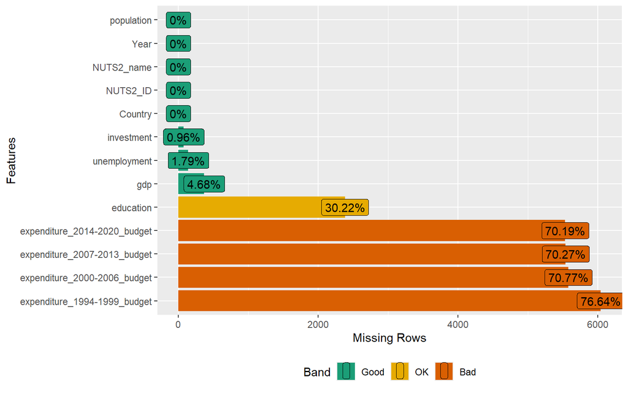

```r
# education data is only from 2000 onward so I am only going to keep data from that year onward

# I will be dropping the budget period which I am not going to use
data <- data |>
  select(-`expenditure_1989-1993_budget`)

plot_missing(data)
```

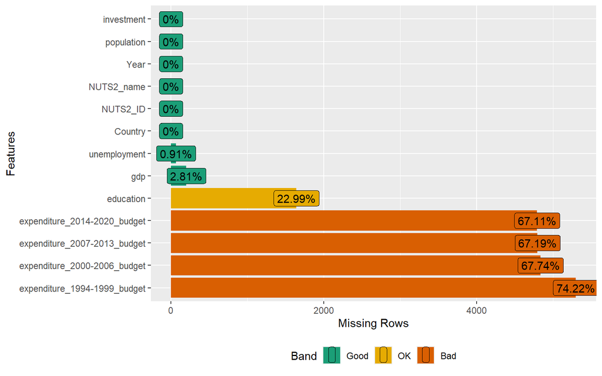

```r
plot_missing(data |> filter(Year>=1993))
```

```r
summary(data |> filter(Year>=1993))
```

```
##    Country            NUTS2_ID          NUTS2_name             Year
##  Length:7141        Length:7141        Length:7141        Min.   :1993
##  Class :character   Class :character   Class :character   1st Qu.:2001
##  Mode  :character   Mode  :character   Mode  :character   Median :2009
##                                                           Mean   :2008
##                                                           3rd Qu.:2016
##                                                           Max.   :2022
##
##  expenditure_1994-1999_budget expenditure_2000-2006_budget
##  Min.   :        0            Min.   :0.000e+00
##  1st Qu.:  2765206            1st Qu.:4.362e+06
##  Median : 10166927            Median :1.581e+07
##  Mean   : 40099707            Mean   :5.080e+07
##  3rd Qu.: 37077081            3rd Qu.:4.588e+07
##  Max.   :828179824            Max.   :1.314e+09
##  NA's   :5300                 NA's   :4837
##  expenditure_2007-2013_budget expenditure_2014-2020_budget  unemployment
##  Min.   :0.000e+00            Min.   :        0            Min.   :   0.20
##  1st Qu.:6.277e+06            1st Qu.:  2885814            1st Qu.:  23.77
##  Median :2.220e+07            Median : 14169083            Median :  45.30
##  Mean   :7.538e+07            Mean   : 61242069            Mean   :  73.96
##  3rd Qu.:8.663e+07            3rd Qu.: 56083473            3rd Qu.:  84.72
##  Max.   :1.710e+09            Max.   :990666787            Max.   :1460.60
##  NA's   :4798                 NA's   :4792                 NA's   :65
##       gdp           population         education       investment
##  Min.   :  3721   Min.   :   25180   Min.   : 3.60   Min.   :   122.5
##  1st Qu.: 19108   1st Qu.:  823570   1st Qu.:19.50   1st Qu.:  3757.9
##  Median : 27600   Median : 1412109   Median :25.90   Median :  7384.5
##  Mean   : 27665   Mean   : 1795307   Mean   :26.39   Mean   : 10470.5
##  3rd Qu.: 34510   3rd Qu.: 2198632   3rd Qu.:32.50   3rd Qu.: 12915.2
##  Max.   :101293   Max.   :12394163   Max.   :60.70   Max.   :167272.8
##  NA's   :201                         NA's   :1642
```

```r
data <- data |>
  filter(Year>=1993)

# Step 1: Set the columns you want to impute
target_vars <- c("education", "gdp")

# Step 2: Create predictor matrix
pred_matrix <- make.predictorMatrix(data)
pred_matrix[, c("Country", "NUTS2_ID", "NUTS2_name", "Year",
                "expenditure_1994-1999_budget", "expenditure_2000-2006_budget",
                "expenditure_2007-2013_budget", "expenditure_2014-2020_budget",
                "population", "investment", "unemployment")] <- 0
pred_matrix[c("Country", "NUTS2_name",
              "expenditure_1994-1999_budget", "expenditure_2000-2006_budget",
              "expenditure_2007-2013_budget", "expenditure_2014-2020_budget"), ] <- 0

# Step 3: Exclude non-target columns from being imputed
method_vec <- rep("", ncol(data))
names(method_vec) <- colnames(data)
method_vec[target_vars] <- "pmm"

# Step 4: Run MICE only on the specified target columns
imputed <- mice(data,
                m = 1,
                method = method_vec,
                predictorMatrix = pred_matrix,
                seed = 123)
# Step 5 (optional): Extract one completed dataset
data <- complete(imputed)

# Check imputed values
summary(data)
```

```
##    Country            NUTS2_ID          NUTS2_name             Year
##  Length:7141        Length:7141        Length:7141        Min.   :1993
##  Class :character   Class :character   Class :character   1st Qu.:2001
##  Mode  :character   Mode  :character   Mode  :character   Median :2009
##                                                           Mean   :2008
##                                                           3rd Qu.:2016
##                                                           Max.   :2022
##
##  expenditure_1994-1999_budget expenditure_2000-2006_budget
##  Min.   :        0            Min.   :0.000e+00
##  1st Qu.:  2765206            1st Qu.:4.362e+06
##  Median : 10166927            Median :1.581e+07
##  Mean   : 40099707            Mean   :5.080e+07
##  3rd Qu.: 37077081            3rd Qu.:4.588e+07
##  Max.   :828179824            Max.   :1.314e+09
##  NA's   :5300                 NA's   :4837
##  expenditure_2007-2013_budget expenditure_2014-2020_budget  unemployment
##  Min.   :0.000e+00            Min.   :        0            Min.   :   0.20
##  1st Qu.:6.277e+06            1st Qu.:  2885814            1st Qu.:  23.77
##  Median :2.220e+07            Median : 14169083            Median :  45.30
##  Mean   :7.538e+07            Mean   : 61242069            Mean   :  73.96
##  3rd Qu.:8.663e+07            3rd Qu.: 56083473            3rd Qu.:  84.72
##  Max.   :1.710e+09            Max.   :990666787            Max.   :1460.60
##  NA's   :4798                 NA's   :4792                 NA's   :65
##       gdp           population         education       investment
##  Min.   :  3721   Min.   :   25180   Min.   : 3.60   Min.   :   122.5
##  1st Qu.: 19135   1st Qu.:  823570   1st Qu.:19.50   1st Qu.:  3757.9
##  Median : 27578   Median : 1412109   Median :25.70   Median :  7384.5
##  Mean   : 27631   Mean   : 1795307   Mean   :26.25   Mean   : 10470.5
##  3rd Qu.: 34464   3rd Qu.: 2198632   3rd Qu.:32.30   3rd Qu.: 12915.2
##  Max.   :101293   Max.   :12394163   Max.   :60.70   Max.   :167272.8
##
```

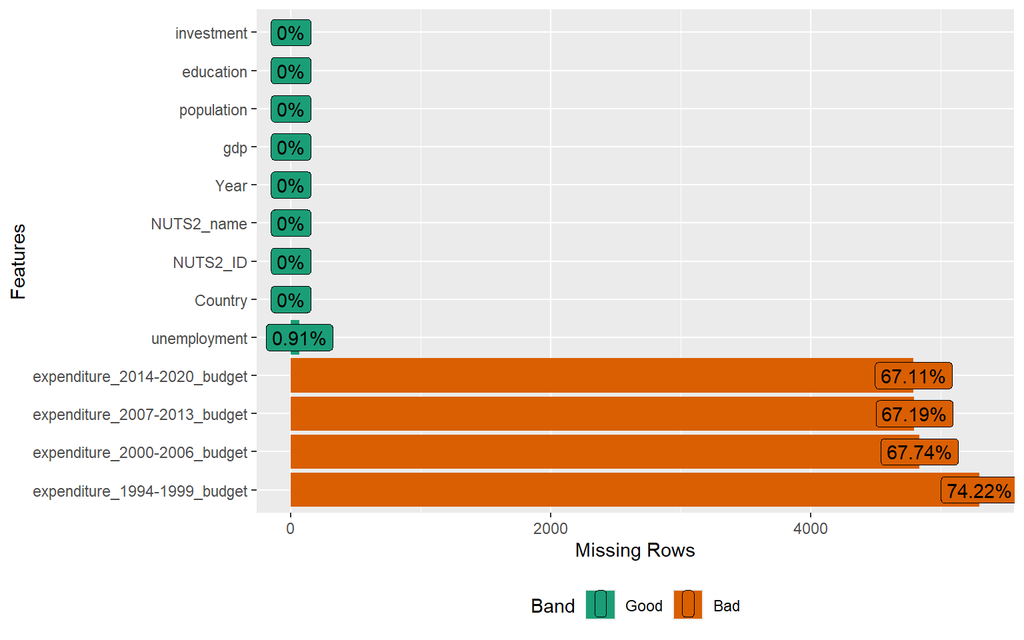

```r
plot_missing(data)
```

## Binary - poor regions

### 2014-2020

Source: [Cohesion Open Data](https://cohesiondata.ec.europa.eu/2014-2020/Regions-by-cohesion-policy-category-2014-2020/b6uw-xiie/about_data) checked from [Commission Implementing decision 2014/99/EU](https://eur-lex.europa.eu/legal-content/EN/TXT/?uri=CELEX:32014D0099#ntr1-L_2014050EN.01002401-E0001)

```r
cat14_20 <- read_csv("data/cat14_20.csv")
# Selecting only the least developed regions
cat14_20 <- cat14_20 |>
  select(nuts_id, catg_name) |>
  filter(catg_name == "Less developed")

# NUTS 2006 used by this categorization vs NUTS 2021 used in our dataset
# Which of these regions is not present in the dataset due to NUTS discrepancies
missing_regions <- anti_join(cat14_20, data, by = c("nuts_id" = "NUTS2_ID"))

# Regions which I have deleted because I couldn't use their data
deleted_regions <- c("FR91", "UKI1", "UKI2", "UKZZ", "IE01", "IE02",
                     "LT00", "HU10", "PL12", "UKM2", "UKM3", "HR04")

# Regions that I should try to identify
missing_regions <- missing_regions |>
  filter(!nuts_id %in% deleted_regions)
missing_regions
```

```
## # A tibble: 14 × 2
##    nuts_id catg_name
##    <chr>   <chr>
##  1 GR11    Less developed
##  2 GR12    Less developed
##  3 GR14    Less developed
##  4 GR21    Less developed
##  5 GR23    Less developed
##  6 FR92    Less developed
##  7 FR93    Less developed
##  8 FR94    Less developed
##  9 PL11    Less developed
## 10 PL31    Less developed
## 11 PL32    Less developed
## 12 PL33    Less developed
## 13 PL34    Less developed
## 14 SI01    Less developed
```

```r
# These are all regions which have undergone only code name changes or minor reshuffling
cat14_20 <- cat14_20 |>
  mutate(nuts_id = case_when(
    nuts_id == "GR11" ~ "EL51",
    nuts_id == "GR12" ~ "EL52",
    nuts_id == "GR14" ~ "EL61",
    nuts_id == "GR21" ~ "EL54",
    nuts_id == "GR23" ~ "EL63",
    nuts_id == "FR92" ~ "FRY2",
    nuts_id == "FR93" ~ "FRY3",
    nuts_id == "FR94" ~ "FRY4",
    nuts_id == "PL11" ~ "PL71",
    nuts_id == "PL31" ~ "PL81",
    nuts_id == "PL32" ~ "PL82",
    nuts_id == "PL33" ~ "PL72",
    nuts_id == "PL34" ~ "PL84",
    nuts_id == "SI01" ~ "SI03",
    TRUE ~ nuts_id
  ))

anti_join(cat14_20, data, by = c("nuts_id" = "NUTS2_ID"))
```

```
## # A tibble: 3 × 2
##   nuts_id catg_name
##   <chr>   <chr>
## 1 FR91    Less developed
## 2 LT00    Less developed
## 3 HR04    Less developed
```

The only regions that have been left out are part of the regions which I have previously deleted above because of boundary shifts. So I join them and make sure they appear for the whole budget period they refer to + n years of implementation

```r
data <- data |>
  left_join(cat14_20, by = c("NUTS2_ID" = "nuts_id")) |>
  rename(poor14_20 = catg_name) |>
  mutate(poor14_20 = case_when(
    Year >= 2014 & is.na(poor14_20) ~ 0,
    Year >= 2014 & poor14_20 == "Less developed" ~ 1,
    Year < 2014 ~ NA,
  ))
```

### 2007-2013

Source: [Cohesion Open Data](https://cohesiondata.ec.europa.eu/2007-2013/Eligible-regions-2007-2013/fz3v-c3qc/about_data), checked from [Commission decision 2006/595/EC](https://eur-lex.europa.eu/legal-content/EN/ALL/?uri=CELEX%3A32006D0595) and [Commission decision 2007/189/EC](https://eur-lex.europa.eu/legal-content/EN/ALL/?uri=CELEX%3A32007D0189)

```r
cat07_13 <- read_csv("data/cat07_13.csv")
# Selecting only the least developed regions
cat07_13 <- cat07_13 |>
  select(nuts_id, objective_code) |>
  filter(objective_code == "Conv")

# Which of these regions is not present in the dataset due to NUTS discrepancies
missing_regions <- anti_join(cat07_13, data, by = c("nuts_id" = "NUTS2_ID"))

# Regions which I have deleted because I couldn't use their data
deleted_regions <- c("FR91", "UKI1", "UKI2", "UKZZ", "IE01", "IE02",
                     "LT00", "HU10", "PL12", "UKM2", "UKM3", "HR04")

# Regions that I should try to identify
missing_regions <- missing_regions |>
  filter(!nuts_id %in% deleted_regions)
missing_regions
```

```
## # A tibble: 35 × 2
##    nuts_id objective_code
##    <chr>   <chr>
##  1 DE41    Conv
##  2 DED1    Conv
##  3 DEE1    Conv
##  4 DEE3    Conv
##  5 GR11    Conv
##  6 GR14    Conv
##  7 GR21    Conv
##  8 GR22    Conv
##  9 GR23    Conv
## 10 GR25    Conv
## # ℹ 25 more rows
```

```r
# These are all regions which have undergone only code name changes or minor reshuffling
cat07_13 <- cat07_13 |>
  mutate(nuts_id = case_when(
    nuts_id == "DE41" ~ "DE40",
    nuts_id == "DED1" ~ "DED4",
    # DEE0 was created by merging DEE1 (poor), DEE2 (phasing out), DEE3 (poor)
    # So I'll consider it poor and I'll convert one of their code into DE00 in here
    # and then deleting the other below
    nuts_id == "DEE1" ~ "DEE0",
    nuts_id == "GR11" ~ "EL51",
    nuts_id == "GR14" ~ "EL61",
    nuts_id == "GR21" ~ "EL54",
    nuts_id == "GR22" ~ "EL62",
    nuts_id == "GR23" ~ "EL63",
    nuts_id == "GR25" ~ "EL65",
    nuts_id == "GR41" ~ "EL41",
    nuts_id == "GR43" ~ "EL43",
    nuts_id == "FR92" ~ "FRY2",
    nuts_id == "FR93" ~ "FRY3",
    nuts_id == "FR94" ~ "FRY4",
    # In the commission decision BG and RO use different codes which are more current
    nuts_id == "BG11" ~ "BG31",
    nuts_id == "BG12" ~ "BG32",
    nuts_id == "BG13" ~ "BG33",
    nuts_id == "BG21" ~ "BG34",
    nuts_id == "BG22" ~ "BG41",
    nuts_id == "BG23" ~ "BG42",
    nuts_id == "PL11" ~ "PL71",
    nuts_id == "PL31" ~ "PL81",
    nuts_id == "PL32" ~ "PL82",
    nuts_id == "PL33" ~ "PL72",
    nuts_id == "PL34" ~ "PL84",
    nuts_id == "RO01" ~ "RO21",
    nuts_id == "RO02" ~ "RO22",
    nuts_id == "RO03" ~ "RO31",
    nuts_id == "RO04" ~ "RO41",
    nuts_id == "RO05" ~ "RO42",
    nuts_id == "RO06" ~ "RO11",
    nuts_id == "RO07" ~ "RO12",
    nuts_id == "RO08" ~ "RO32",
    TRUE ~ nuts_id
  )) |>
  filter(nuts_id != "DEE3") |>
  # Slovenia SI00 was split into SI01 and SI02 which are then recoded as SI03 and SI04
  # So I need to add those two lines
  filter(nuts_id != "SI00") |>
  rbind(c("SI03", "Conv")) |>
  rbind(c("SI04", "Conv"))

anti_join(cat07_13, data, by = c("nuts_id" = "NUTS2_ID"))
```

```
## # A tibble: 3 × 2
##   nuts_id objective_code
##   <chr>   <chr>
## 1 FR91    Conv
## 2 LT00    Conv
## 3 PL12    Conv
```

The only regions that have been left out are part of the regions which I have previously deleted above because of boundary shifts. So I join them and make sure they appear for the whole budget period they refer to + n years of implementation

```r
data <- data |>
  left_join(cat07_13, by = c("NUTS2_ID" = "nuts_id")) |>
  rename(poor07_13 = objective_code) |>
  mutate(poor07_13 = case_when(
    Year >= 2007 & Year <=2015 & is.na(poor07_13) ~ 0,
    Year >= 2007 & Year <=2015 & poor07_13 == "Conv" ~ 1,
    Year < 2007 ~ NA,
    Year > 2015 ~ NA
  ))
```

### 2000-2006

Source: [Cohesion Open Data](https://cohesiondata.ec.europa.eu/2000-2006/Eligible-population-2000-2006/4f9w-qbvh/about_data), checked from [Commission decision 1999/502/EC](https://eur-lex.europa.eu/legal-content/EN/TXT/?uri=CELEX%3A01999D0502-20040501)

```r
cat00_06 <- read_csv("data/cat00_06.csv")
cat00_06 <- cat00_06 |>
  # Selecting only the least developed regions: objective 1
  filter(pop_obj1 > 0) |>
  # Converting NUTS3 into NUTS2 codes
  mutate(nuts_id = substr(nuts_id, 1, 4)) |>
  pull(nuts_id) |>
  unique()

# Adding a dummy which will then be merged
cat00_06 <- tibble(nuts_id = cat00_06) |>
  mutate(objective_code = 1)

# Which of these regions is not present in the dataset due to NUTS discrepancies
missing_regions <- anti_join(cat00_06, data, by = c("nuts_id" = "NUTS2_ID"))

# Regions which I have deleted because I couldn't use their data
deleted_regions <- c("FR91", "UKI1", "UKI2", "UKZZ", "IE01", "IE02",
                     "LT00", "HU10", "PL12", "UKM2", "UKM3", "HR04")

# Regions that I should try to identify
missing_regions <- missing_regions |>
  filter(!nuts_id %in% deleted_regions)
missing_regions
```

```
## # A tibble: 35 × 2
##    nuts_id objective_code
##    <chr>            <dbl>
##  1 DE41                 1
##  2 DE42                 1
##  3 DED1                 1
##  4 DED3                 1
##  5 DEE1                 1
##  6 DEE2                 1
##  7 DEE3                 1
##  8 GR11                 1
##  9 GR12                 1
## 10 GR13                 1
## # ℹ 25 more rows
```

```r
# These are all regions which have undergone only code name changes or minor reshuffling
cat00_06 <- cat00_06 |>
  mutate(nuts_id = case_when(
    # DE40 was created by merging DE41 (poor), and DE42 (poor)
    # So I'll consider it poor and I'll convert one of their code into DE40 in here
    # and then deleting the other below
    nuts_id == "DE41" ~ "DE40",
    nuts_id == "DED1" ~ "DED4",
    nuts_id == "DED3" ~ "DED5",
    # DEE0 was created by merging DEE1 (poor), DEE2 (poor), DEE3 (poor)
    # So I'll consider it poor and I'll convert one of their code into DE00 in here
    # and then deleting the other below
    nuts_id == "DEE1" ~ "DEE0",
    nuts_id == "GR11" ~ "EL51",
    nuts_id == "GR12" ~ "EL52",
    nuts_id == "GR13" ~ "EL53",
    nuts_id == "GR14" ~ "EL61",
    nuts_id == "GR21" ~ "EL54",
    nuts_id == "GR22" ~ "EL62",
    nuts_id == "GR23" ~ "EL63",
    nuts_id == "GR24" ~ "EL64",
    nuts_id == "GR25" ~ "EL65",
    nuts_id == "GR30" ~ "EL30",
    nuts_id == "GR41" ~ "EL41",
    nuts_id == "GR42" ~ "EL42",
    nuts_id == "GR43" ~ "EL43",
    nuts_id == "FR92" ~ "FRY2",
    nuts_id == "FR93" ~ "FRY3",
    nuts_id == "FR94" ~ "FRY4",
    nuts_id == "PL11" ~ "PL71",
    nuts_id == "PL31" ~ "PL81",
    nuts_id == "PL32" ~ "PL82",
    nuts_id == "PL33" ~ "PL72",
    nuts_id == "PL34" ~ "PL84",
    # FI1D was created by merging FI13 (poor), FI1A (poor)
    # So I'll consider it poor and I'll convert one of their code into FI1D in here
    # and then deleting the other below
    nuts_id == "FI13" ~ "FI1D",
    nuts_id == "SE06" ~ "SE31",
    nuts_id == "SE07" ~ "SE32",
    nuts_id == "SE08" ~ "SE33",
    nuts_id == "UKD5" ~ "UKD7",
    TRUE ~ nuts_id
  )) |>
  filter(nuts_id != "DE42") |>
  filter(nuts_id != "DEE3") |>
  filter(nuts_id != "DEE2") |>
  filter(nuts_id != "FI1A") |>
  # Slovenia SI00 was split into SI01 and SI02 which are then recoded as SI03 and SI04
  # So I need to add those two lines
  filter(nuts_id != "SI00") |>
  rbind(c("SI03", 1)) |>
  rbind(c("SI04", 1))

anti_join(cat00_06, data, by = c("nuts_id" = "NUTS2_ID"))
```

```
## # A tibble: 5 × 2
##   nuts_id objective_code
##   <chr>   <chr>
## 1 IE01    1
## 2 FR91    1
## 3 LT00    1
## 4 HU10    1
## 5 PL12    1
```

The only regions that have been left out are part of the regions which I have previously deleted above because of boundary shifts. So I join them and make sure they appear for the whole budget period they refer to + n years of implementation

```r
data <- data |>
  left_join(cat00_06, by = c("NUTS2_ID" = "nuts_id")) |>
  rename(poor00_06 = objective_code) |>
  mutate(poor00_06 = case_when(
    Year >= 2000 & Year <=2009 & is.na(poor00_06) ~ 0,
    Year >= 2000 & Year <=2009 & poor00_06 == 1 ~ 1,
    Year < 2000 ~ NA,
    Year > 2009 ~ NA,
  )) |>
  # Fixing for 07 enlargment
  mutate(poor00_06 = case_when(
    Country %in% c("RO", "BG") & Year %in% c(2007, 2008, 2009) ~ NA,
    TRUE ~ poor00_06
  ))
```

# Exploratory data analysis - Graphs

Total expenditure per year

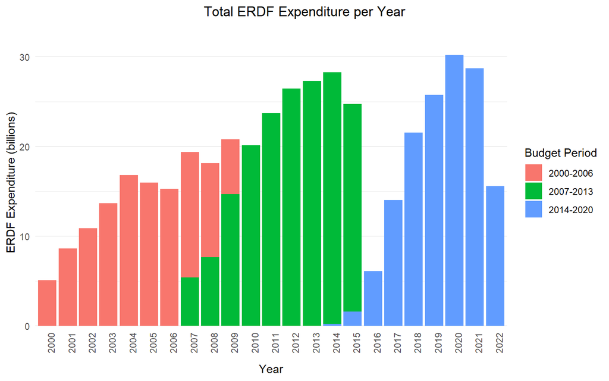

```r
data_graph <- data |>
  filter(Year >= 2000) |>
  group_by(Year) |>
  # Calculating total expenditure per year per budget period
  summarise(expenditure00_06 = sum(`expenditure_2000-2006_budget`, na.rm = TRUE),
            expenditure07_13 = sum(`expenditure_2007-2013_budget`, na.rm = TRUE),
            expenditure14_20 = sum(`expenditure_2014-2020_budget`, na.rm = TRUE)) |>
  pivot_longer(cols = starts_with("expenditure"),
               names_to = "budget_period",
               values_to = "expenditure") |>
  filter(expenditure > 0) |>
  # Modifying in order to have expenditure in billions
  # Plus modifying budget period for readibility
  mutate(expenditure = expenditure / 1000000000,
         budget_period = case_when(
           budget_period == "expenditure00_06" ~ "2000-2006",
           budget_period == "expenditure07_13" ~ "2007-2013",
           budget_period == "expenditure14_20" ~ "2014-2020"))

p <- ggplot(data_graph, aes(x = as.factor(Year),
                            y = expenditure,
                            fill = budget_period)) +
  geom_col() +
  labs(
    title = "Total ERDF Expenditure per Year",
    x = "Year",
    y = "ERDF Expenditure (billions)",
    fill = "Budget Period"
  ) +
  theme_minimal() +
  ylim(0, 32) +
  theme(axis.text.x = element_text(angle = 90, margin = margin(t = -10)),
        axis.title.x = element_text(margin = margin(t = 10)),
        panel.grid.major.x = element_blank(),
        plot.title = element_text(hjust = 0.5),
        plot.title.position = "plot")
p
```

```r
# ggsave("tot_exp_barplot.png", plot = p, width = 8, height = 4.5, dpi = 300)
```

Maps for 2000-2006 budget period

```r
# Select 00-06 data
data_graph <- data |>
  mutate(across(starts_with("expenditure"), ~ .x/population)) |>
  select(Country, NUTS2_ID, "expenditure_2000-2006_budget", poor00_06) |>
  drop_na() |>
  summarise(mean_exp = mean(`expenditure_2000-2006_budget`, na.rm = TRUE),
            .by = c("Country", "NUTS2_ID", "poor00_06"))

# Get NUTS2 map
nuts2_map <- get_eurostat_geospatial(
  nuts_level = 2,
  year = 2021,
  resolution = "10",
  output_class = "sf",
  crs = "3035")
```

```
## Extracting data using giscoR package, please report issues on https://github.com/rOpenGov/giscoR/issues
```

```
## Cache management as per giscoR. see 'giscoR::gisco_get_nuts()'
```

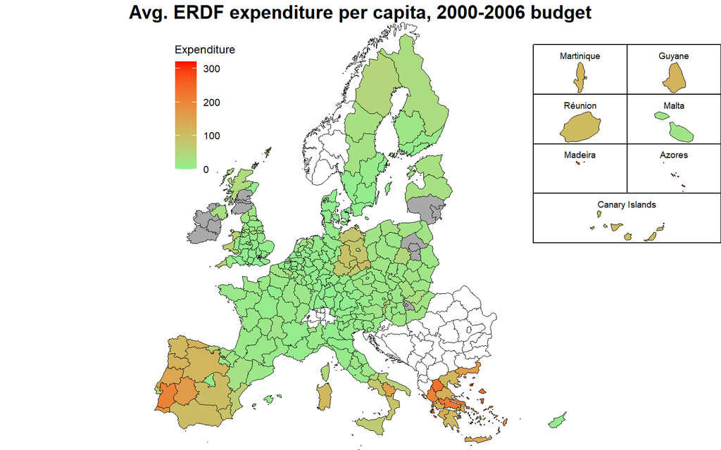

```r
# Exclude Turkey, Iceland and Svalbard
nuts2_map <- nuts2_map %>%
  filter(!CNTR_CODE %in% c("TR", "IS")) |>
  filter(!NUTS_ID == "NO0B")

# Set a vector containing non-Eu countries present in the above df
non_eu <- c("AL", "CH", "ME", "MK", "LI", "RS", "NO", "BG", "HR", "RO")

# Join data to main df and mutate fill color
nuts2_map <- nuts2_map |>
  left_join(data_graph, by = join_by("NUTS_ID" == "NUTS2_ID")) |>
  mutate(fill_color = case_when(
    CNTR_CODE %in% non_eu ~ "white",
    poor00_06 == 1 ~ "red",
    poor00_06 == 0 ~ "lightgreen",
    is.na(poor00_06) ~ "darkgrey")) |>
  mutate(is_non_eu = CNTR_CODE %in% non_eu)

# Get full range across all regions
global_range <- range(nuts2_map$mean_exp, na.rm = TRUE)
# Set common gradient scale
shared_gradient_scale <- scale_fill_gradient(
  low = "lightgreen", high = "red", na.value = "darkgrey",
  limits = global_range,
  name = "Expenditure"
)

# Territories which I do not want plotted
overseas_codes <- c(
  "ES70", # Canary Islands
  "FRY1", # Guadeloupe
  "FRY2", # Martinique
  "FRY3", # Guyane
  "FRY4", # Réunion
  "FRY5", # Mayotte
  "PT20", # Azores
  "PT30", # Madeira
  "MT00"  # Malta
)

# Main map dataframe excluding overseas
main_map <- filter(nuts2_map, !NUTS_ID %in% overseas_codes)

# Helper function for inset maps with title and border
make_inset <- function(data, title) {
  ggplot(data) +
    geom_sf(aes(fill = mean_exp), color = "black") +
    shared_gradient_scale +
    theme_void() +
    labs(title = title) +
    theme(plot.title = element_text(size = 7, hjust = 0.5),
          legend.position = "none")}

# Create inset maps - no guadalupte and mayotte because no expenditure data for them
inset_canary     <- make_inset(filter(nuts2_map, NUTS_ID == "ES70"), "Canary Islands")
# inset_guadeloupe <- make_inset(filter(nuts2_map, NUTS_ID == "FRY1"), "Guadeloupe")
inset_martinique <- make_inset(filter(nuts2_map, NUTS_ID == "FRY2"), "Martinique")
inset_guyane     <- make_inset(filter(nuts2_map, NUTS_ID == "FRY3"), "Guyane")
inset_reunion    <- make_inset(filter(nuts2_map, NUTS_ID == "FRY4"), "Réunion")
# inset_mayotte    <- make_inset(filter(nuts2_map, NUTS_ID == "FRY5"), "Mayotte")
inset_azores     <- make_inset(filter(nuts2_map, NUTS_ID == "PT20"), "Azores")
inset_madeira    <- make_inset(filter(nuts2_map, NUTS_ID == "PT30"), "Madeira")
inset_malta       <- make_inset(filter(nuts2_map, NUTS_ID == "MT00"), "Malta")

# Draw the plot of continental Europe
main_plot <- ggplot(main_map) +
  geom_sf(aes(fill = mean_exp), color = "black") +
  shared_gradient_scale +
  theme_void() +
  theme(
    plot.margin = unit(c(0, 0, 0, 0), "cm"),
    legend.position = c(0.05, 0.95),
    legend.justification = c(0, 1),
    legend.background = element_rect(fill = NA, color = NA),
    legend.title = element_text(size = 9),
    legend.text = element_text(size = 8)) +
  coord_sf(expand = FALSE)
# Non-EU overlay
non_eu_overlay <- ggplot(main_map) +
  geom_sf(aes(fill = is_non_eu), color = "black") +
  scale_fill_manual(
    values = c("TRUE" = "white", "FALSE" = NA),
    na.value = NA,
    guide = "none") +
  theme_void() +
  theme(
    plot.margin = unit(c(0, 0, 0, 0), "cm")) +
  coord_sf(expand = FALSE)

# Combine all
final_map <- ggdraw() +
  # Main map
  draw_plot(main_plot, x = 0, y = 0, width = 1, height = 0.95) +
  draw_plot(non_eu_overlay, x = 0, y = 0, width = 1, height = 0.95) +

  # Drawing rectangles to fill in the inset areas
  draw_grob(rectGrob(x = 0.805, y = 0.845, width = 0.13, height = 0.11,
                     gp = gpar(col = "black", fill = "white", lwd = 1))) +
  draw_grob(rectGrob(x = 0.935, y = 0.845, width = 0.13, height = 0.11,
                     gp = gpar(col = "black", fill = "white", lwd = 1))) +
  draw_grob(rectGrob(x = 0.805, y = 0.735, width = 0.13, height = 0.11,
                     gp = gpar(col = "black", fill = "white", lwd = 1))) +
  draw_grob(rectGrob(x = 0.935, y = 0.735, width = 0.13, height = 0.11,
                     gp = gpar(col = "black", fill = "white", lwd = 1))) +
  draw_grob(rectGrob(x = 0.805, y = 0.625, width = 0.13, height = 0.11,
                     gp = gpar(col = "black", fill = "white", lwd = 1))) +
  draw_grob(rectGrob(x = 0.935, y = 0.625, width = 0.13, height = 0.11,
                     gp = gpar(col = "black", fill = "white", lwd = 1))) +
  draw_grob(rectGrob(x = 0.87, y = 0.515, width = 0.26, height = 0.11,
                     gp = gpar(col = "black", fill = "white", lwd = 1))) +

  # Row by row insets
  draw_plot(inset_martinique, x = 0.74, y = 0.79, width = 0.13, height = 0.11) +
  draw_plot(inset_guyane,     x = 0.87, y = 0.79, width = 0.13, height = 0.11) +

  draw_plot(inset_reunion,    x = 0.74, y = 0.68, width = 0.13, height = 0.11) +
  draw_plot(inset_malta,      x = 0.87, y = 0.68, width = 0.13, height = 0.11) +

  draw_plot(inset_madeira,    x = 0.74, y = 0.57, width = 0.13, height = 0.11) +
  draw_plot(inset_azores,     x = 0.87, y = 0.57, width = 0.13, height = 0.11) +

  draw_plot(inset_canary,     x = 0.74, y = 0.46, width = 0.26, height = 0.11) +

  # Plot title
  draw_label("Avg. ERDF expenditure per capita, 2000-2006 budget",
             x = 0.5,
             y = 0.99,
             fontface = 'bold',
             size = 15,
             hjust = 0.5,
             vjust = 1)

final_map
```

```r
# ggsave("map00_06_exp.png", plot = final_map, width = 6, height = 6, dpi = 500)
```

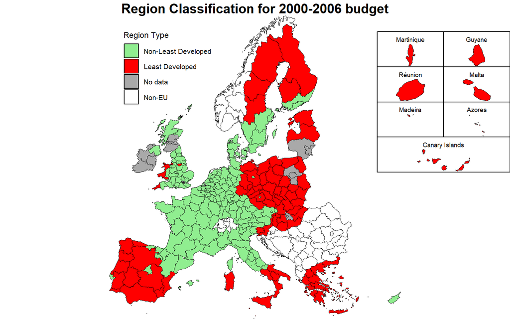

```r
# Helper function for inset maps with title and border
make_inset <- function(data, title) {
  ggplot(data) +
    geom_sf(aes(fill = fill_color), color = "black") +
    scale_fill_identity() +
    theme_void() +
    labs(title = title) +
    theme(plot.title = element_text(size = 7, hjust = 0.5))}

# Create inset maps - no guadalupte and mayotte because no expenditure data for them
inset_canary     <- make_inset(filter(nuts2_map, NUTS_ID == "ES70"), "Canary Islands")
# inset_guadeloupe <- make_inset(filter(nuts2_map, NUTS_ID == "FRY1"), "Guadeloupe")
inset_martinique <- make_inset(filter(nuts2_map, NUTS_ID == "FRY2"), "Martinique")
inset_guyane     <- make_inset(filter(nuts2_map, NUTS_ID == "FRY3"), "Guyane")
inset_reunion    <- make_inset(filter(nuts2_map, NUTS_ID == "FRY4"), "Réunion")
# inset_mayotte    <- make_inset(filter(nuts2_map, NUTS_ID == "FRY5"), "Mayotte")
inset_azores     <- make_inset(filter(nuts2_map, NUTS_ID == "PT20"), "Azores")
inset_madeira    <- make_inset(filter(nuts2_map, NUTS_ID == "PT30"), "Madeira")
inset_malta       <- make_inset(filter(nuts2_map, NUTS_ID == "MT00"), "Malta")

# Draw the plot of continental Europe
main_plot <- ggplot(main_map) +
  geom_sf(aes(fill = fill_color), color = "black") +
  scale_fill_identity(
  name = "Region Type",
  breaks = c("lightgreen", "red", "darkgrey", "white"),
  labels = c("Non-Least Developed", "Least Developed", "No data", "Non-EU"),
  guide = "legend") +
  theme_void() +
  theme(plot.margin = unit(c(0, 0, 0, 0), "cm"),
        legend.position = c(0.05, 0.95),
        legend.justification = c(0, 1),
        legend.background = element_rect(fill = NA, color = NA),
        legend.title = element_text(size = 9),
        legend.text = element_text(size = 8)) +
  coord_sf(expand = FALSE)

# Combine all
final_map <- ggdraw() +
  # Main map
  draw_plot(main_plot, x = 0, y = 0, width = 1, height = 0.95) +

  # Drawing rectangles to fill in the inset areas
  draw_grob(rectGrob(x = 0.805, y = 0.845, width = 0.13, height = 0.11,
                     gp = gpar(col = "black", fill = "white", lwd = 1))) +
  draw_grob(rectGrob(x = 0.935, y = 0.845, width = 0.13, height = 0.11,
                     gp = gpar(col = "black", fill = "white", lwd = 1))) +
  draw_grob(rectGrob(x = 0.805, y = 0.735, width = 0.13, height = 0.11,
                     gp = gpar(col = "black", fill = "white", lwd = 1))) +
  draw_grob(rectGrob(x = 0.935, y = 0.735, width = 0.13, height = 0.11,
                     gp = gpar(col = "black", fill = "white", lwd = 1))) +
  draw_grob(rectGrob(x = 0.805, y = 0.625, width = 0.13, height = 0.11,
                     gp = gpar(col = "black", fill = "white", lwd = 1))) +
  draw_grob(rectGrob(x = 0.935, y = 0.625, width = 0.13, height = 0.11,
                     gp = gpar(col = "black", fill = "white", lwd = 1))) +
  draw_grob(rectGrob(x = 0.87, y = 0.515, width = 0.26, height = 0.11,
                     gp = gpar(col = "black", fill = "white", lwd = 1))) +

  # Row by row insets
  draw_plot(inset_martinique, x = 0.74, y = 0.79, width = 0.13, height = 0.11) +
  draw_plot(inset_guyane,     x = 0.87, y = 0.79, width = 0.13, height = 0.11) +

  draw_plot(inset_reunion,    x = 0.74, y = 0.68, width = 0.13, height = 0.11) +
  draw_plot(inset_malta,      x = 0.87, y = 0.68, width = 0.13, height = 0.11) +

  draw_plot(inset_madeira,    x = 0.74, y = 0.57, width = 0.13, height = 0.11) +
  draw_plot(inset_azores,     x = 0.87, y = 0.57, width = 0.13, height = 0.11) +

  draw_plot(inset_canary,     x = 0.74, y = 0.46, width = 0.26, height = 0.11) +

  # Plot title
  draw_label("Region Classification for 2000-2006 budget",
             x = 0.5,
             y = 0.99,
             fontface = 'bold',
             size = 15,
             hjust = 0.5,
             vjust = 1)

final_map
```

```r
# ggsave("map00_06.png", plot = final_map, width = 6, height = 6, dpi = 500)
```

Map for 2007-2013 budget period

```r
# Select 07-13 data
data_graph <- data |>
  mutate(across(starts_with("expenditure"), ~ .x/population)) |>
  select(Country, NUTS2_ID, "expenditure_2007-2013_budget", poor07_13) |>
  drop_na() |>
  summarise(mean_exp = mean(`expenditure_2007-2013_budget`, na.rm = TRUE),
            .by = c("Country", "NUTS2_ID", "poor07_13"))

# Get NUTS2 map
nuts2_map <- get_eurostat_geospatial(
  nuts_level = 2,
  year = 2021,
  resolution = "10",
  output_class = "sf",
  crs = "3035")
```

```
## Extracting data using giscoR package, please report issues on https://github.com/rOpenGov/giscoR/issues
```

```
## Cache management as per giscoR. see 'giscoR::gisco_get_nuts()'
```

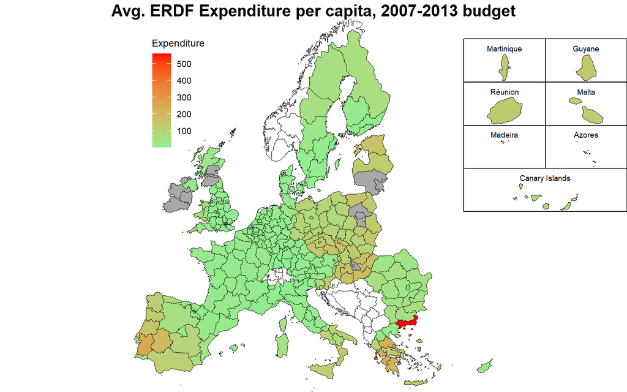

```r
# Exclude Turkey, Iceland and Svalbard
nuts2_map <- nuts2_map %>%
  filter(!CNTR_CODE %in% c("TR", "IS")) |>
  filter(!NUTS_ID == "NO0B")

# Set a vector containing non-Eu countries present in the above df
non_eu <- c("AL", "CH", "ME", "MK", "LI", "RS", "NO", "HR")

# Join data to main df and mutate fill color
nuts2_map <- nuts2_map |>
  left_join(data_graph, by = join_by("NUTS_ID" == "NUTS2_ID")) |>
  mutate(fill_color = case_when(
    CNTR_CODE %in% non_eu ~ "white",
    poor07_13 == 1 ~ "red",
    poor07_13 == 0 ~ "lightgreen",
    is.na(poor07_13) ~ "darkgrey")) |>
  mutate(is_non_eu = CNTR_CODE %in% non_eu)

# Get full range across all regions
global_range <- range(nuts2_map$mean_exp, na.rm = TRUE)
# Set common gradient scale
shared_gradient_scale <- scale_fill_gradient(
  low = "lightgreen", high = "red", na.value = "darkgrey",
  limits = global_range,
  name = "Expenditure"
)

# Territories which I do not want plotted
overseas_codes <- c(
  "ES70", # Canary Islands
  "FRY1", # Guadeloupe
  "FRY2", # Martinique
  "FRY3", # Guyane
  "FRY4", # Réunion
  "FRY5", # Mayotte
  "PT20", # Azores
  "PT30", # Madeira
  "MT00"  # Malta
)

# Main map dataframe excluding overseas
main_map <- filter(nuts2_map, !NUTS_ID %in% overseas_codes)

# Helper function for inset maps with title and border
make_inset <- function(data, title) {
  ggplot(data) +
    geom_sf(aes(fill = mean_exp), color = "black") +
    shared_gradient_scale +
    theme_void() +
    labs(title = title) +
    theme(plot.title = element_text(size = 7, hjust = 0.5),
          legend.position = "none")}

# Create inset maps - no guadalupte and mayotte because no expenditure data for them
inset_canary     <- make_inset(filter(nuts2_map, NUTS_ID == "ES70"), "Canary Islands")
# inset_guadeloupe <- make_inset(filter(nuts2_map, NUTS_ID == "FRY1"), "Guadeloupe")
inset_martinique <- make_inset(filter(nuts2_map, NUTS_ID == "FRY2"), "Martinique")
inset_guyane     <- make_inset(filter(nuts2_map, NUTS_ID == "FRY3"), "Guyane")
inset_reunion    <- make_inset(filter(nuts2_map, NUTS_ID == "FRY4"), "Réunion")
# inset_mayotte    <- make_inset(filter(nuts2_map, NUTS_ID == "FRY5"), "Mayotte")
inset_azores     <- make_inset(filter(nuts2_map, NUTS_ID == "PT20"), "Azores")
inset_madeira    <- make_inset(filter(nuts2_map, NUTS_ID == "PT30"), "Madeira")
inset_malta       <- make_inset(filter(nuts2_map, NUTS_ID == "MT00"), "Malta")

# Draw the plot of continental Europe
main_plot <- ggplot(main_map) +
  geom_sf(aes(fill = mean_exp), color = "black") +
  shared_gradient_scale +
  theme_void() +
  theme(
    plot.margin = unit(c(0, 0, 0, 0), "cm"),
    legend.position = c(0.05, 0.95),
    legend.justification = c(0, 1),
    legend.background = element_rect(fill = NA, color = NA),
    legend.title = element_text(size = 9),
    legend.text = element_text(size = 8)) +
  coord_sf(expand = FALSE)

# Non-EU overlay
non_eu_overlay <- ggplot(main_map) +
  geom_sf(aes(fill = is_non_eu), color = "black") +
  scale_fill_manual(
    values = c("TRUE" = "white", "FALSE" = NA),
    na.value = NA,
    guide = "none") +
  theme_void() +
  theme(
    plot.margin = unit(c(0, 0, 0, 0), "cm")) +
  coord_sf(expand = FALSE)

# Combine all
final_map <- ggdraw() +
  # Main map
  draw_plot(main_plot, x = 0, y = 0, width = 1, height = 0.95) +
  draw_plot(non_eu_overlay, x = 0, y = 0, width = 1, height = 0.95) +

  # Drawing rectangles to fill in the inset areas
  draw_grob(rectGrob(x = 0.805, y = 0.845, width = 0.13, height = 0.11,
                     gp = gpar(col = "black", fill = "white", lwd = 1))) +
  draw_grob(rectGrob(x = 0.935, y = 0.845, width = 0.13, height = 0.11,
                     gp = gpar(col = "black", fill = "white", lwd = 1))) +
  draw_grob(rectGrob(x = 0.805, y = 0.735, width = 0.13, height = 0.11,
                     gp = gpar(col = "black", fill = "white", lwd = 1))) +
  draw_grob(rectGrob(x = 0.935, y = 0.735, width = 0.13, height = 0.11,
                     gp = gpar(col = "black", fill = "white", lwd = 1))) +
  draw_grob(rectGrob(x = 0.805, y = 0.625, width = 0.13, height = 0.11,
                     gp = gpar(col = "black", fill = "white", lwd = 1))) +
  draw_grob(rectGrob(x = 0.935, y = 0.625, width = 0.13, height = 0.11,
                     gp = gpar(col = "black", fill = "white", lwd = 1))) +
  draw_grob(rectGrob(x = 0.87, y = 0.515, width = 0.26, height = 0.11,
                     gp = gpar(col = "black", fill = "white", lwd = 1))) +

  # Row by row insets
  draw_plot(inset_martinique, x = 0.74, y = 0.79, width = 0.13, height = 0.11) +
  draw_plot(inset_guyane,     x = 0.87, y = 0.79, width = 0.13, height = 0.11) +

  draw_plot(inset_reunion,    x = 0.74, y = 0.68, width = 0.13, height = 0.11) +
  draw_plot(inset_malta,      x = 0.87, y = 0.68, width = 0.13, height = 0.11) +

  draw_plot(inset_madeira,    x = 0.74, y = 0.57, width = 0.13, height = 0.11) +
  draw_plot(inset_azores,     x = 0.87, y = 0.57, width = 0.13, height = 0.11) +

  draw_plot(inset_canary,     x = 0.74, y = 0.46, width = 0.26, height = 0.11) +

  # Plot title
  draw_label("Avg. ERDF Expenditure per capita, 2007-2013 budget",
             x = 0.5,
             y = 0.99,
             fontface = 'bold',
             size = 15,
             hjust = 0.5,
             vjust = 1)

final_map
```

```r
# ggsave("map07_13_exp.png", plot = final_map, width = 6, height = 6, dpi = 500)
```

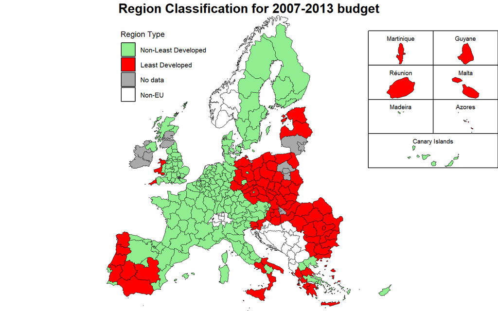

```r
# Helper function for inset maps with title and border
make_inset <- function(data, title) {
  ggplot(data) +
    geom_sf(aes(fill = fill_color), color = "black") +
    scale_fill_identity() +
    theme_void() +
    labs(title = title) +
    theme(plot.title = element_text(size = 7, hjust = 0.5))}

# Create inset maps - no guadalupte and mayotte because no expenditure data for them
inset_canary     <- make_inset(filter(nuts2_map, NUTS_ID == "ES70"), "Canary Islands")
# inset_guadeloupe <- make_inset(filter(nuts2_map, NUTS_ID == "FRY1"), "Guadeloupe")
inset_martinique <- make_inset(filter(nuts2_map, NUTS_ID == "FRY2"), "Martinique")
inset_guyane     <- make_inset(filter(nuts2_map, NUTS_ID == "FRY3"), "Guyane")
inset_reunion    <- make_inset(filter(nuts2_map, NUTS_ID == "FRY4"), "Réunion")
# inset_mayotte    <- make_inset(filter(nuts2_map, NUTS_ID == "FRY5"), "Mayotte")
inset_azores     <- make_inset(filter(nuts2_map, NUTS_ID == "PT20"), "Azores")
inset_madeira    <- make_inset(filter(nuts2_map, NUTS_ID == "PT30"), "Madeira")
inset_malta       <- make_inset(filter(nuts2_map, NUTS_ID == "MT00"), "Malta")

# Draw the plot of continental Europe
main_plot <- ggplot(main_map) +
  geom_sf(aes(fill = fill_color), color = "black") +
  scale_fill_identity(
  name = "Region Type",
  breaks = c("lightgreen", "red", "darkgrey", "white"),
  labels = c("Non-Least Developed", "Least Developed", "No data", "Non-EU"),
  guide = "legend") +
  theme_void() +
  theme(plot.margin = unit(c(0, 0, 0, 0), "cm"),
        legend.position = c(0.05, 0.95),
        legend.justification = c(0, 1),
        legend.background = element_rect(fill = NA, color = NA),
        legend.title = element_text(size = 9),
        legend.text = element_text(size = 8)) +
  coord_sf(expand = FALSE)

# Combine all
final_map <- ggdraw() +
  # Main map
  draw_plot(main_plot, x = 0, y = 0, width = 1, height = 0.95) +

  # Drawing rectangles to fill in the inset areas
  draw_grob(rectGrob(x = 0.805, y = 0.845, width = 0.13, height = 0.11,
                     gp = gpar(col = "black", fill = "white", lwd = 1))) +
  draw_grob(rectGrob(x = 0.935, y = 0.845, width = 0.13, height = 0.11,
                     gp = gpar(col = "black", fill = "white", lwd = 1))) +
  draw_grob(rectGrob(x = 0.805, y = 0.735, width = 0.13, height = 0.11,
                     gp = gpar(col = "black", fill = "white", lwd = 1))) +
  draw_grob(rectGrob(x = 0.935, y = 0.735, width = 0.13, height = 0.11,
                     gp = gpar(col = "black", fill = "white", lwd = 1))) +
  draw_grob(rectGrob(x = 0.805, y = 0.625, width = 0.13, height = 0.11,
                     gp = gpar(col = "black", fill = "white", lwd = 1))) +
  draw_grob(rectGrob(x = 0.935, y = 0.625, width = 0.13, height = 0.11,
                     gp = gpar(col = "black", fill = "white", lwd = 1))) +
  draw_grob(rectGrob(x = 0.87, y = 0.515, width = 0.26, height = 0.11,
                     gp = gpar(col = "black", fill = "white", lwd = 1))) +

  # Row by row insets
  draw_plot(inset_martinique, x = 0.74, y = 0.79, width = 0.13, height = 0.11) +
  draw_plot(inset_guyane,     x = 0.87, y = 0.79, width = 0.13, height = 0.11) +

  draw_plot(inset_reunion,    x = 0.74, y = 0.68, width = 0.13, height = 0.11) +
  draw_plot(inset_malta,      x = 0.87, y = 0.68, width = 0.13, height = 0.11) +

  draw_plot(inset_madeira,    x = 0.74, y = 0.57, width = 0.13, height = 0.11) +
  draw_plot(inset_azores,     x = 0.87, y = 0.57, width = 0.13, height = 0.11) +

  draw_plot(inset_canary,     x = 0.74, y = 0.46, width = 0.26, height = 0.11) +

  # Plot title
  draw_label("Region Classification for 2007-2013 budget",
             x = 0.5,
             y = 0.99,
             fontface = 'bold',
             size = 15,
             hjust = 0.5,
             vjust = 1)

final_map
```

```r
# ggsave("map07_13.png", plot = final_map, width = 6, height = 6, dpi = 500)
```

Map for 2014-2020 budget period

```r
# Select 14-20 data
data_graph <- data |>
  mutate(across(starts_with("expenditure"), ~ .x/population)) |>
  select(Country, NUTS2_ID, "expenditure_2014-2020_budget", poor14_20) |>
  drop_na() |>
  summarise(mean_exp = mean(`expenditure_2014-2020_budget`, na.rm = TRUE),
            .by = c("Country", "NUTS2_ID", "poor14_20"))

# Get NUTS2 map
nuts2_map <- get_eurostat_geospatial(
  nuts_level = 2,
  year = 2021,
  resolution = "10",
  output_class = "sf",
  crs = "3035")
```

```
## Extracting data using giscoR package, please report issues on https://github.com/rOpenGov/giscoR/issues
```

```
## Cache management as per giscoR. see 'giscoR::gisco_get_nuts()'
```

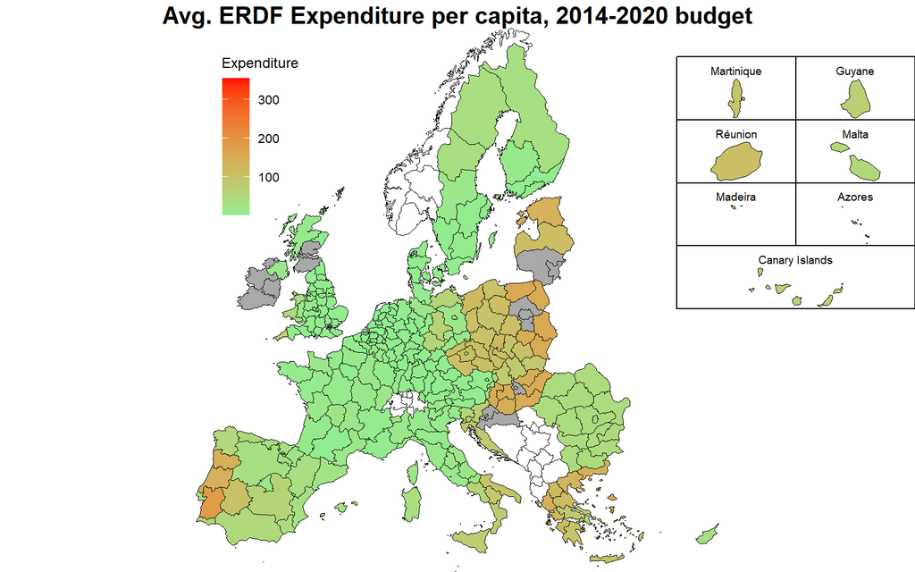

```r
# Exclude Turkey, Iceland and Svalbard
nuts2_map <- nuts2_map %>%
  filter(!CNTR_CODE %in% c("TR", "IS")) |>
  filter(!NUTS_ID == "NO0B")

# Set a vector containing non-Eu countries present in the above df
non_eu <- c("AL", "CH", "ME", "MK", "LI", "RS", "NO")

# Join data to main df and mutate fill color
nuts2_map <- nuts2_map |>
  left_join(data_graph, by = join_by("NUTS_ID" == "NUTS2_ID")) |>
  mutate(fill_color = case_when(
    CNTR_CODE %in% non_eu ~ "white",
    poor14_20 == 1 ~ "red",
    poor14_20 == 0 ~ "lightgreen",
    is.na(poor14_20) ~ "darkgrey")) |>
  mutate(is_non_eu = CNTR_CODE %in% non_eu)

# Get full range across all regions
global_range <- range(nuts2_map$mean_exp, na.rm = TRUE)
# Set common gradient scale
shared_gradient_scale <- scale_fill_gradient(
  low = "lightgreen", high = "red", na.value = "darkgrey",
  limits = global_range,
  name = "Expenditure"
)

# Territories which I do not want plotted
overseas_codes <- c(
  "ES70", # Canary Islands
  "FRY1", # Guadeloupe
  "FRY2", # Martinique
  "FRY3", # Guyane
  "FRY4", # Réunion
  "FRY5", # Mayotte
  "PT20", # Azores
  "PT30", # Madeira
  "MT00"  # Malta
)

# Main map dataframe excluding overseas
main_map <- filter(nuts2_map, !NUTS_ID %in% overseas_codes)

# Helper function for inset maps with title and border
make_inset <- function(data, title) {
  ggplot(data) +
    geom_sf(aes(fill = mean_exp), color = "black") +
    shared_gradient_scale +
    theme_void() +
    labs(title = title) +
    theme(plot.title = element_text(size = 7, hjust = 0.5),
          legend.position = "none")}

# Create inset maps - no guadalupte and mayotte because no expenditure data for them
inset_canary     <- make_inset(filter(nuts2_map, NUTS_ID == "ES70"), "Canary Islands")
# inset_guadeloupe <- make_inset(filter(nuts2_map, NUTS_ID == "FRY1"), "Guadeloupe")
inset_martinique <- make_inset(filter(nuts2_map, NUTS_ID == "FRY2"), "Martinique")
inset_guyane     <- make_inset(filter(nuts2_map, NUTS_ID == "FRY3"), "Guyane")
inset_reunion    <- make_inset(filter(nuts2_map, NUTS_ID == "FRY4"), "Réunion")
# inset_mayotte    <- make_inset(filter(nuts2_map, NUTS_ID == "FRY5"), "Mayotte")
inset_azores     <- make_inset(filter(nuts2_map, NUTS_ID == "PT20"), "Azores")
inset_madeira    <- make_inset(filter(nuts2_map, NUTS_ID == "PT30"), "Madeira")
inset_malta       <- make_inset(filter(nuts2_map, NUTS_ID == "MT00"), "Malta")

# Draw the plot of continental Europe
main_plot <- ggplot(main_map) +
  geom_sf(aes(fill = mean_exp), color = "black") +
  shared_gradient_scale +
  theme_void() +
  theme(
    plot.margin = unit(c(0, 0, 0, 0), "cm"),
    legend.position = c(0.05, 0.95),
    legend.justification = c(0, 1),
    legend.background = element_rect(fill = NA, color = NA),
    legend.title = element_text(size = 9),
    legend.text = element_text(size = 8)) +
  coord_sf(expand = FALSE)

# Non-EU overlay
non_eu_overlay <- ggplot(main_map) +
  geom_sf(aes(fill = is_non_eu), color = "black") +
  scale_fill_manual(
    values = c("TRUE" = "white", "FALSE" = NA),
    na.value = NA,
    guide = "none") +
  theme_void() +
  theme(
    plot.margin = unit(c(0, 0, 0, 0), "cm")) +
  coord_sf(expand = FALSE)

# Combine all
final_map <- ggdraw() +
  # Main map
  draw_plot(main_plot, x = 0, y = 0, width = 1, height = 0.95) +
  draw_plot(non_eu_overlay, x = 0, y = 0, width = 1, height = 0.95) +

  # Drawing rectangles to fill in the inset areas
  draw_grob(rectGrob(x = 0.805, y = 0.845, width = 0.13, height = 0.11,
                     gp = gpar(col = "black", fill = "white", lwd = 1))) +
  draw_grob(rectGrob(x = 0.935, y = 0.845, width = 0.13, height = 0.11,
                     gp = gpar(col = "black", fill = "white", lwd = 1))) +
  draw_grob(rectGrob(x = 0.805, y = 0.735, width = 0.13, height = 0.11,
                     gp = gpar(col = "black", fill = "white", lwd = 1))) +
  draw_grob(rectGrob(x = 0.935, y = 0.735, width = 0.13, height = 0.11,
                     gp = gpar(col = "black", fill = "white", lwd = 1))) +
  draw_grob(rectGrob(x = 0.805, y = 0.625, width = 0.13, height = 0.11,
                     gp = gpar(col = "black", fill = "white", lwd = 1))) +
  draw_grob(rectGrob(x = 0.935, y = 0.625, width = 0.13, height = 0.11,
                     gp = gpar(col = "black", fill = "white", lwd = 1))) +
  draw_grob(rectGrob(x = 0.87, y = 0.515, width = 0.26, height = 0.11,
                     gp = gpar(col = "black", fill = "white", lwd = 1))) +

  # Row by row insets
  draw_plot(inset_martinique, x = 0.74, y = 0.79, width = 0.13, height = 0.11) +
  draw_plot(inset_guyane,     x = 0.87, y = 0.79, width = 0.13, height = 0.11) +

  draw_plot(inset_reunion,    x = 0.74, y = 0.68, width = 0.13, height = 0.11) +
  draw_plot(inset_malta,      x = 0.87, y = 0.68, width = 0.13, height = 0.11) +

  draw_plot(inset_madeira,    x = 0.74, y = 0.57, width = 0.13, height = 0.11) +
  draw_plot(inset_azores,     x = 0.87, y = 0.57, width = 0.13, height = 0.11) +

  draw_plot(inset_canary,     x = 0.74, y = 0.46, width = 0.26, height = 0.11) +

  # Plot title
  draw_label("Avg. ERDF Expenditure per capita, 2014-2020 budget",
             x = 0.5,
             y = 0.99,
             fontface = 'bold',
             size = 15,
             hjust = 0.5,
             vjust = 1)

final_map
```

```r
# ggsave("map14_20_exp.png", plot = final_map, width = 6, height = 6, dpi = 500)
```

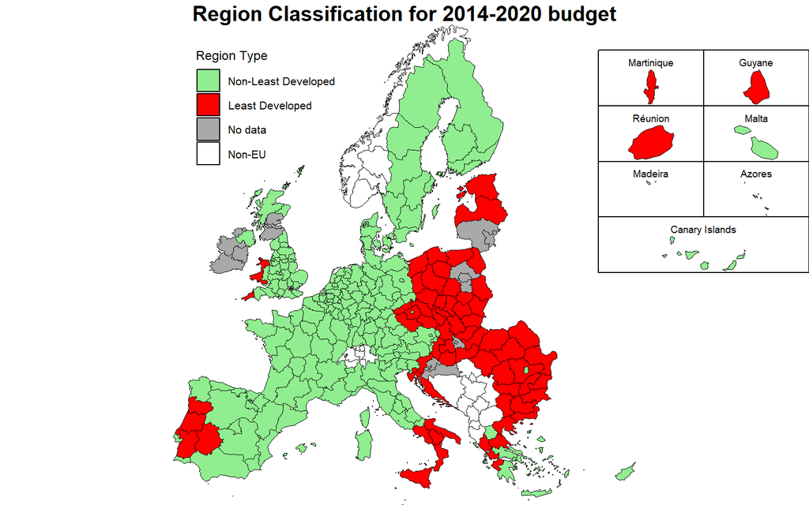

```r
# Helper function for inset maps with title and border
make_inset <- function(data, title) {
  ggplot(data) +
    geom_sf(aes(fill = fill_color), color = "black") +
    scale_fill_identity() +
    theme_void() +
    labs(title = title) +
    theme(plot.title = element_text(size = 7, hjust = 0.5))}

# Create inset maps - no guadalupte and mayotte because no expenditure data for them
inset_canary     <- make_inset(filter(nuts2_map, NUTS_ID == "ES70"), "Canary Islands")
# inset_guadeloupe <- make_inset(filter(nuts2_map, NUTS_ID == "FRY1"), "Guadeloupe")
inset_martinique <- make_inset(filter(nuts2_map, NUTS_ID == "FRY2"), "Martinique")
inset_guyane     <- make_inset(filter(nuts2_map, NUTS_ID == "FRY3"), "Guyane")
inset_reunion    <- make_inset(filter(nuts2_map, NUTS_ID == "FRY4"), "Réunion")
# inset_mayotte    <- make_inset(filter(nuts2_map, NUTS_ID == "FRY5"), "Mayotte")
inset_azores     <- make_inset(filter(nuts2_map, NUTS_ID == "PT20"), "Azores")
inset_madeira    <- make_inset(filter(nuts2_map, NUTS_ID == "PT30"), "Madeira")
inset_malta       <- make_inset(filter(nuts2_map, NUTS_ID == "MT00"), "Malta")

# Draw the plot of continental Europe
main_plot <- ggplot(main_map) +
  geom_sf(aes(fill = fill_color), color = "black") +
  scale_fill_identity(
  name = "Region Type",
  breaks = c("lightgreen", "red", "darkgrey", "white"),
  labels = c("Non-Least Developed", "Least Developed", "No data", "Non-EU"),
  guide = "legend") +
  theme_void() +
  theme(plot.margin = unit(c(0, 0, 0, 0), "cm"),
        legend.position = c(0.05, 0.95),
        legend.justification = c(0, 1),
        legend.background = element_rect(fill = NA, color = NA),
        legend.title = element_text(size = 9),
        legend.text = element_text(size = 8)) +
  coord_sf(expand = FALSE)

# Combine all
final_map <- ggdraw() +
  # Main map
  draw_plot(main_plot, x = 0, y = 0, width = 1, height = 0.95) +

  # Drawing rectangles to fill in the inset areas
  draw_grob(rectGrob(x = 0.805, y = 0.845, width = 0.13, height = 0.11,
                     gp = gpar(col = "black", fill = "white", lwd = 1))) +
  draw_grob(rectGrob(x = 0.935, y = 0.845, width = 0.13, height = 0.11,
                     gp = gpar(col = "black", fill = "white", lwd = 1))) +
  draw_grob(rectGrob(x = 0.805, y = 0.735, width = 0.13, height = 0.11,
                     gp = gpar(col = "black", fill = "white", lwd = 1))) +
  draw_grob(rectGrob(x = 0.935, y = 0.735, width = 0.13, height = 0.11,
                     gp = gpar(col = "black", fill = "white", lwd = 1))) +
  draw_grob(rectGrob(x = 0.805, y = 0.625, width = 0.13, height = 0.11,
                     gp = gpar(col = "black", fill = "white", lwd = 1))) +
  draw_grob(rectGrob(x = 0.935, y = 0.625, width = 0.13, height = 0.11,
                     gp = gpar(col = "black", fill = "white", lwd = 1))) +
  draw_grob(rectGrob(x = 0.87, y = 0.515, width = 0.26, height = 0.11,
                     gp = gpar(col = "black", fill = "white", lwd = 1))) +

  # Row by row insets
  draw_plot(inset_martinique, x = 0.74, y = 0.79, width = 0.13, height = 0.11) +
  draw_plot(inset_guyane,     x = 0.87, y = 0.79, width = 0.13, height = 0.11) +

  draw_plot(inset_reunion,    x = 0.74, y = 0.68, width = 0.13, height = 0.11) +
  draw_plot(inset_malta,      x = 0.87, y = 0.68, width = 0.13, height = 0.11) +

  draw_plot(inset_madeira,    x = 0.74, y = 0.57, width = 0.13, height = 0.11) +
  draw_plot(inset_azores,     x = 0.87, y = 0.57, width = 0.13, height = 0.11) +

  draw_plot(inset_canary,     x = 0.74, y = 0.46, width = 0.26, height = 0.11) +

  # Plot title
  draw_label("Region Classification for 2014-2020 budget",
             x = 0.5,
             y = 0.99,
             fontface = 'bold',
             size = 15,
             hjust = 0.5,
             vjust = 1)

final_map
```

```r
# ggsave("map14_20.png", plot = final_map, width = 6, height = 6, dpi = 500)
```

Table per country

```r
country_summary <- data |>
  mutate(unemployment = ((unemployment*1000)/population)*1000) |>
  mutate(investment = (investment*1000000/population)) |>
  mutate(tot_exp = rowSums(across(starts_with("expenditure")), na.rm = TRUE)) |>
  group_by(Country) |>
  summarise(
    n_regions = n_distinct(NUTS2_ID),
    sum_exp = sum(tot_exp, na.rm = TRUE)/1000000,
    avg_unemployment = mean(unemployment, na.rm = TRUE),
    avg_gdp = mean(gdp, na.rm = TRUE),
    avg_investment = mean(investment, na.rm = TRUE),
    avg_education = mean(education, na.rm = TRUE),
    .groups = "drop"
  ) |>
  mutate(Country = case_when(
    Country == "AT" ~ "Austria",
    Country == "BE" ~ "Belgium",
    Country == "BG" ~ "Bulgaria",
    Country == "CY" ~ "Cyprus",
    Country == "CZ" ~ "Czech Republic",
    Country == "DE" ~ "Germany",
    Country == "DK" ~ "Denmark",
    Country == "EE" ~ "Estonia",
    Country == "EL" ~ "Greece",
    Country == "ES" ~ "Spain",
    Country == "FI" ~ "Finland",
    Country == "FR" ~ "France",
    Country == "HR" ~ "Croatia",
    Country == "HU" ~ "Hungary",
    Country == "IT" ~ "Italy",
    Country == "LU" ~ "Luxembourg",
    Country == "LV" ~ "Latvia",
    Country == "MT" ~ "Malta",
    Country == "NL" ~ "Netherlands",
    Country == "PL" ~ "Poland",
    Country == "PT" ~ "Portugal",
    Country == "RO" ~ "Romania",
    Country == "SE" ~ "Sweden",
    Country == "SI" ~ "Slovenia",
    Country == "SK" ~ "Slovakia",
    Country == "UK" ~ "United Kingdom")) |>
  arrange(Country)

table_country <- country_summary |>
  gt() |>
  tab_header(
    title = "Average Economic Indicators by Country",
    subtitle = "Aggregated over the full 2000–2022 period or since EU accession"
  ) |>
  cols_label(
    Country = "Country",
    n_regions = "N. of Regions",
    sum_exp = "Total ERDF Expenditure",
    avg_unemployment = "Unemployment",
    avg_gdp = "Real GDP",
    avg_investment = "Investment",
    avg_education = "Education",
  ) |>
  fmt_number(
    columns = c(avg_gdp, avg_investment, sum_exp),
    decimals = 0,
    use_seps = TRUE
  ) |>
  fmt_number(
    columns = c(avg_education, avg_unemployment),
    decimals = 1,
    use_seps = TRUE
  ) |>
  cols_align(
    align = "center",
    columns = c(avg_unemployment, avg_gdp, avg_investment, avg_education)
  ) |>
  cols_align(
    align = "right",
    columns = c(n_regions, sum_exp)
  ) |>
  tab_spanner(
    label = "Economic Indicators (Country Averages)",
    columns = c(avg_unemployment, avg_gdp, avg_investment, avg_education)
  ) |>
  tab_source_note("Note: Expenditure in millions €; GDP and investment per capita in €; number of unemployed per 1000 people; % of population aged 25–64 with tertiary education."
  ) |>
  tab_options(
    heading.background.color = "#f8f9fa",
    column_labels.background.color = "#e9ecef",
    source_notes.background.color = "#f8f9fa"
  )
table_country
```

Average Economic Indicators by Country

| Country | N. of Regions | Total ERDF Expenditure | Economic Indicators (Country Averages) Unemployment | Economic Indicators (Country Averages) Real GDP | Economic Indicators (Country Averages) Investment | Economic Indicators (Country Averages) Education |
| --- | --- | --- | --- | --- | --- | --- |
| Austria | 9 | 2,453 | 22.7 | 36,497 | 8,805 | 23.4 |
| Belgium | 11 | 3,324 | 33.6 | 32,950 | 7,599 | 34.0 |
| Bulgaria | 6 | 5,707 | 39.2 | 5,918 | 1,213 | 24.1 |
| Croatia | 1 | 1,073 | 47.5 | 11,554 | 2,750 | 24.6 |
| Cyprus | 1 | 587 | 42.3 | 23,458 | 4,576 | 38.8 |
| Czech Republic | 8 | 23,427 | 26.0 | 16,020 | 4,193 | 19.5 |
| Denmark | 5 | 685 | 30.5 | 42,386 | 8,523 | 32.3 |
| Estonia | 1 | 3,739 | 40.8 | 15,747 | 4,323 | 36.9 |
| Finland | 5 | 3,036 | 43.3 | 38,257 | 8,704 | 35.1 |
| France | 25 | 26,380 | 44.6 | 26,423 | 5,675 | 26.1 |
| Germany | 38 | 47,682 | 34.4 | 33,189 | 6,822 | 26.2 |
| Greece | 13 | 46,017 | 60.3 | 15,235 | 3,064 | 21.4 |
| Hungary | 6 | 20,132 | 32.4 | 8,797 | 2,342 | 17.4 |
| Italy | 21 | 67,625 | 39.2 | 28,290 | 5,886 | 17.7 |
| Latvia | 1 | 4,685 | 52.4 | 11,556 | 2,950 | 29.7 |
| Luxembourg | 1 | 132 | 19.8 | 88,533 | 15,370 | 36.6 |
| Malta | 1 | 729 | 25.0 | 21,470 | 4,286 | 20.1 |
| Netherlands | 12 | 2,812 | 28.3 | 35,245 | 7,433 | 30.2 |
| Poland | 15 | 66,418 | 39.3 | 9,607 | 1,812 | 23.5 |
| Portugal | 7 | 45,294 | 40.5 | 17,852 | 3,715 | 18.1 |
| Romania | 8 | 15,584 | 27.7 | 8,760 | 2,177 | 16.3 |
| Slovakia | 4 | 10,073 | 51.9 | 16,769 | 3,907 | 22.7 |
| Slovenia | 2 | 3,302 | 32.3 | 19,550 | 4,263 | 29.2 |
| Spain | 19 | 87,131 | 75.5 | 21,826 | 4,605 | 29.2 |
| Sweden | 8 | 2,877 | 39.7 | 39,884 | 8,948 | 32.8 |
| United Kingdom | 33 | 20,447 | 28.5 | 32,602 | 6,010 | 30.7 |

Note: Expenditure in millions €; GDP and investment per capita in €; number of unemployed per 1000 people; % of population aged 25–64 with tertiary education.

```r
# gtsave(table_country, filename = "country_descriptive.png")
```

# Regressions

## Getting ready for regression

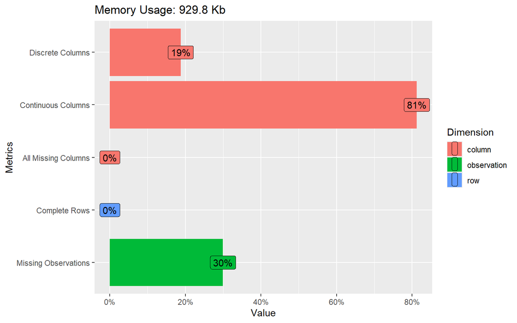

```r
plot_intro(data)
```

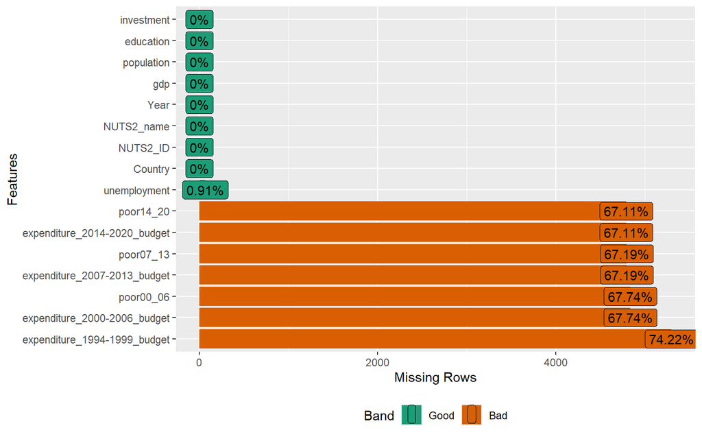

```r
plot_missing(data)
```

```r
str(data)
```

```
## 'data.frame':    7141 obs. of  16 variables:
##  $ Country                     : chr  "AT" "AT" "AT" "AT" ...
##  $ NUTS2_ID                    : chr  "AT11" "AT11" "AT11" "AT11" ...
##  $ NUTS2_name                  : chr  "Burgenland" "Burgenland" "Burgenland" "Burgenland" ...
##  $ Year                        : num  1995 1996 1997 1998 1999 ...
##  $ expenditure_1994-1999_budget: num  12558474 11500040 21217727 25183719 22855217 ...
##  $ expenditure_2000-2006_budget: num  NA NA NA NA NA ...
##  $ expenditure_2007-2013_budget: num  NA NA NA NA NA NA NA NA NA NA ...
##  $ expenditure_2014-2020_budget: num  NA NA NA NA NA NA NA NA NA NA ...
##  $ unemployment                : num  6.1 6.8 6.7 6.5 6.4 6.4 6.3 6.3 7.6 6.9 ...
##  $ gdp                         : num  18368 18913 19844 20926 21623 ...
##  $ population                  : num  277687 277706 277389 276972 276480 ...
##  $ education                   : num  11.6 23.2 33.4 23.7 22.7 11 11.2 11.6 12.6 12.6 ...
##  $ investment                  : num  1275 1346 1376 1406 1428 ...
##  $ poor14_20                   : num  NA NA NA NA NA NA NA NA NA NA ...
##  $ poor07_13                   : num  NA NA NA NA NA NA NA NA NA NA ...
##  $ poor00_06                   : num  NA NA NA NA NA 1 1 1 1 1 ...
```

Modifying some variables

```r
data <- data |>
  mutate(across(starts_with("expenditure"), ~ .x/population)) |>
  mutate(unemployment = ((unemployment*1000)/population)*1000) |>
  mutate(investment = (investment*1000000/population)) |>
  arrange(NUTS2_ID, Year)

data <- data |>
  select(-population)
```

I will now handle missing data in unemployment variable.

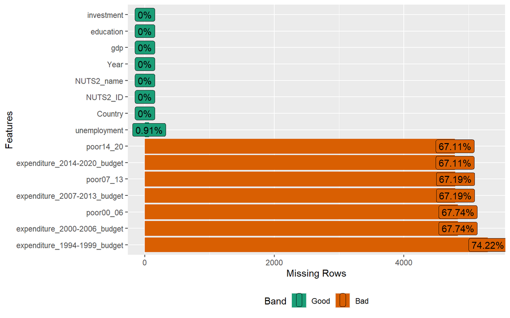

```r
plot_missing(data)
```

```r
data |> filter(is.na(unemployment))
```

```
##    Country NUTS2_ID                   NUTS2_name Year
## 1       FI     FI19                  Länsi-Suomi 1995
## 2       FI     FI19                  Länsi-Suomi 1996
## 3       FI     FI19                  Länsi-Suomi 1997
## 4       FI     FI19                  Länsi-Suomi 1998
## 5       FI     FI1B             Helsinki-Uusimaa 1995
## 6       FI     FI1B             Helsinki-Uusimaa 1996
## 7       FI     FI1B             Helsinki-Uusimaa 1997
## 8       FI     FI1B             Helsinki-Uusimaa 1998
## 9       FI     FI1C                  Etelä-Suomi 1995
## 10      FI     FI1C                  Etelä-Suomi 1996
## 11      FI     FI1C                  Etelä-Suomi 1997
## 12      FI     FI1C                  Etelä-Suomi 1998
## 13      FI     FI1D        Pohjois- ja Itä-Suomi 1995
## 14      FI     FI1D        Pohjois- ja Itä-Suomi 1996
```

[output cut: 249 more lines]

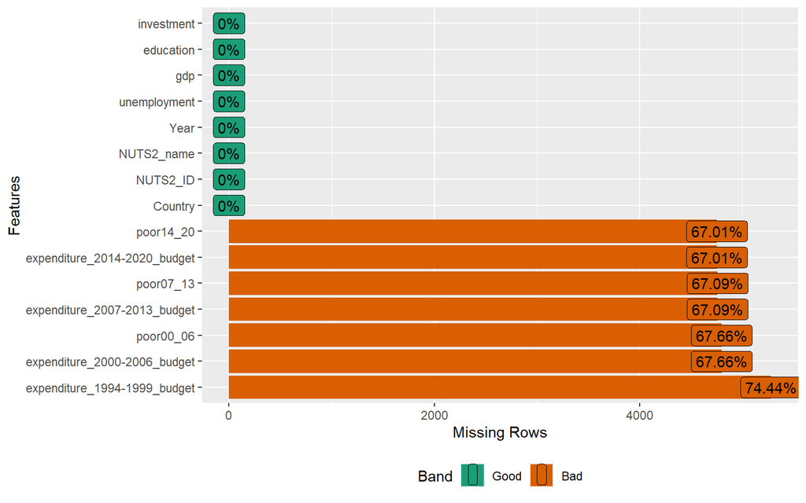

```r
# Finland has no unemployment data before 2000
# FI20 has no unemployment data ever
# For the others I will use the mean between the last available data (done manually)
# FRY2 --> 90.424615 1999 to 2000
# FRY3 --> 94.09213 1999 to 2000
# FRY4 --> 110.508205 1999 to 2000
# ITC2 --> 14.90351 1999 to 2004
# PT20 --> 11.958335 2001 to 2002
# PT20 --> 15.89781 2005 to 2006
# PT30 --> 13.675395 2001 to 2002
# UKE2 --> 22.149575 2001
# UKK3 --> 21.150545 2003
# UKM6 --> 12.15795 2019

data <- data |>
  mutate(unemployment = case_when(
    NUTS2_ID == "FI20" ~ NA_real_,
    NUTS2_ID == "FRY2" & Year == 2000 ~ 90.424615,
    NUTS2_ID == "FRY2" & Year == 1999 ~ 90.424615,
    NUTS2_ID == "FRY3" & Year == 2000 ~ 94.09213,
    NUTS2_ID == "FRY3" & Year == 1999 ~ 94.09213,
    NUTS2_ID == "FRY4" & Year == 2000 ~ 110.508205,
    NUTS2_ID == "FRY4" & Year == 1999 ~ 110.508205,
    NUTS2_ID == "ITC2" & Year == 2004 ~ 14.90351,
    NUTS2_ID == "ITC2" & Year == 2003 ~ 14.90351,
    NUTS2_ID == "ITC2" & Year == 2002 ~ 14.90351,
    NUTS2_ID == "ITC2" & Year == 2001 ~ 14.90351,
    NUTS2_ID == "ITC2" & Year == 2000 ~ 14.90351,
    NUTS2_ID == "ITC2" & Year == 1999 ~ 14.90351,
    NUTS2_ID == "PT20" & Year == 2002 ~ 11.958335,
    NUTS2_ID == "PT20" & Year == 2001 ~ 11.958335,
    NUTS2_ID == "PT20" & Year == 2006 ~ 15.89781,
    NUTS2_ID == "PT20" & Year == 2005 ~ 15.89781,
    NUTS2_ID == "PT30" & Year == 2002 ~ 13.675395,
    NUTS2_ID == "PT30" & Year == 2001 ~ 13.675395,
    NUTS2_ID == "UKE2" & Year == 2001 ~ 22.149575,
    NUTS2_ID == "UKK3" & Year == 2003 ~ 21.150545,
    NUTS2_ID == "UKM6" & Year == 2019 ~ 12.15795,
    TRUE ~ unemployment
  ))

# Drop Finland before 2000 and FI20 always
data <- data |>
  filter(!(Country == "FI" & Year < 2000)) |>
  filter(!(NUTS2_ID == "FI20"))

plot_missing(data)
```

```r
data <- data |>
  select(-"expenditure_1994-1999_budget")
```

Now I have: 1) expenditure per capita 2) number of unemployed per 1000 people 3) binary for poor regions 4) GDP per capita 5) investment per capita 6) % of people with tertiary education

Expected coefficients expenditure -> negative GDP -> negative education -> negative investment -> negative poor binaries -> positive interaction -> negative

## Exploratory data analysis - tables

```r
# Create summary for each budget period
create_period_summary <- function(data, period_name, poor_var, expenditure_var) {

  # Filter out missing values using the poverty indicator
  period_data <- data[!is.na(data[[poor_var]]), ]

  # Create poverty status labels
  period_data$poverty_status <- ifelse(period_data[[poor_var]] == 1, "Least Developed", "Non Least Developed")

  # Calculate summary statistics
  summary_stats <- period_data |>
    group_by(poverty_status) |>
    summarise(
      n_regions = n_distinct(NUTS2_ID),
      avg_expenditure = mean(get(expenditure_var), na.rm = TRUE),
      avg_unemployment = mean(unemployment, na.rm = TRUE),
      avg_gdp = mean(gdp, na.rm = TRUE),
      avg_education = mean(education, na.rm = TRUE),
      avg_investment = mean(investment, na.rm = TRUE),
      .groups = 'drop'
    ) |>
    mutate(budget_period = period_name)

  return(summary_stats)
}

# Generate summaries for each period
summary_2000_2006 <- create_period_summary(data, "2000-2006", "poor00_06", "expenditure_2000-2006_budget")
summary_2007_2013 <- create_period_summary(data, "2007-2013", "poor07_13", "expenditure_2007-2013_budget")
summary_2014_2020 <- create_period_summary(data, "2014-2020", "poor14_20", "expenditure_2014-2020_budget")

# Combine all summaries
final_summary <- bind_rows(summary_2000_2006, summary_2007_2013, summary_2014_2020)

# Reorder columns for better presentation
final_summary <- final_summary |>
  select(budget_period, poverty_status, n_regions, avg_expenditure,
         avg_unemployment, avg_gdp, avg_investment, avg_education)

table_gt <- final_summary |>
  # Arrange data by budget period, then poverty status
  arrange(budget_period, poverty_status) |>
  # Group by budget period
  gt(groupname_col = "budget_period") |>
  tab_header(
    title = "Regional Economic Indicators by Budget Period",
    subtitle = "Comparison between Least Developed and Non Least Developed Regions"
  ) |>
  cols_label(
    poverty_status = "",
    n_regions = "N. of Obs.",
    avg_expenditure = "ERDF Expenditure",
    avg_unemployment = "Unemployment",
    avg_gdp = "Real GDP",
    avg_investment = "Investment",
    avg_education = "Education") |>
  fmt_number(
    columns = c(avg_gdp, avg_investment, avg_expenditure,
                avg_unemployment, avg_education),
    decimals = 0,
    use_seps = TRUE) |>
  fmt_number(
    columns = c(avg_expenditure, avg_unemployment, avg_education),
    decimals = 1,
    use_seps = TRUE) |>
  cols_align(
    align = "center",
    columns = c(n_regions, avg_expenditure, avg_unemployment,
                avg_gdp, avg_investment, avg_education)) |>
  tab_spanner(
    label = "Economic Indicators (Average per Budget Period)",
    columns = c(avg_expenditure, avg_unemployment,
                avg_gdp, avg_investment, avg_education)
  ) |>
  tab_source_note("Note: Expenditure, GDP and investment per capita in €; number of unemployed per 1000 people; % of population aged 25–64 with tertiary education.") |>
  tab_options(
    heading.background.color = "#f8f9fa",
    column_labels.background.color = "#e9ecef",
    row_group.background.color = "#f1f3f4",
    source_notes.background.color = "#f8f9fa")

table_gt
```

Regional Economic Indicators by Budget Period

Comparison between Least Developed and Non Least Developed Regions

|  | N. of Obs. | Economic Indicators (Average per Budget Period) ERDF Expenditure | Economic Indicators (Average per Budget Period) Unemployment | Economic Indicators (Average per Budget Period) Real GDP | Economic Indicators (Average per Budget Period) Investment | Economic Indicators (Average per Budget Period) Education |
| --- | --- | --- | --- | --- | --- | --- |
| 2000-2006 |  |  |  |  |  |  |
| Least Developed | 92 | 90.4 | 51.2 | 17,903 | 4,245 | 18.7 |
| Non Least Developed | 153 | 10.6 | 29.7 | 33,790 | 7,101 | 24.4 |
| 2007-2013 |  |  |  |  |  |  |
| Least Developed | 81 | 124.2 | 51.3 | 13,101 | 2,868 | 20.2 |
| Non Least Developed | 179 | 18.1 | 39.2 | 33,550 | 6,853 | 28.4 |
| 2014-2020 |  |  |  |  |  |  |
| Least Developed | 68 | 103.2 | 38.0 | 12,838 | 2,623 | 23.6 |
| Non Least Developed | 192 | 18.0 | 35.2 | 34,049 | 7,098 | 33.0 |

Note: Expenditure, GDP and investment per capita in €; number of unemployed per 1000 people; % of population aged 25–64 with tertiary education.

```r
# gtsave(table_gt, filename = "descriptive_summary.png")
```

```r
# # Summarizing average unemployment by NUTS2 region
#
# data_map <- data |>
#   group_by(NUTS2_ID) |>
#   summarise(avg_unemployment = mean(unemployment, na.rm = TRUE), .groups = "drop")
#
# # Get NUTS2 map
# nuts2_map <- get_eurostat_geospatial(
#   nuts_level = 2,
#   year = 2021,
#   resolution = "10",
#   output_class = "sf",
#   crs = "3035")
#
# # Exclude Turkey, Iceland and Svalbard
# nuts2_map <- nuts2_map %>%
#   filter(!CNTR_CODE %in% c("TR", "IS")) |>
#   filter(!NUTS_ID == "NO0B")
#
# # Set a vector containing non-Eu countries present in the above df
# non_eu <- c("AL", "CH", "ME", "MK", "LI", "RS", "NO")
#
# # Join data to main df and mutate fill color
# nuts2_map <- nuts2_map |>
#   left_join(data_map, by = join_by("NUTS_ID" == "NUTS2_ID")) |>
#   mutate(is_non_eu = CNTR_CODE %in% non_eu)
#
# # Get full range across all regions
# global_range <- range(nuts2_map$avg_unemployment, na.rm = TRUE)
# # Set common gradient scale
# shared_gradient_scale <- scale_fill_gradient(
#   low = "lightgreen", high = "red", na.value = "darkgrey",
#   limits = global_range,
#   name = "Unemployment"
# )
#
# # Territories which I do not want plotted
# overseas_codes <- c(
#   "ES70", # Canary Islands
#   "FRY1", # Guadeloupe
#   "FRY2", # Martinique
#   "FRY3", # Guyane
#   "FRY4", # Réunion
#   "FRY5", # Mayotte
#   "PT20", # Azores
#   "PT30", # Madeira
#   "MT00"  # Malta
# )
#
# # Main map dataframe excluding overseas
# main_map <- filter(nuts2_map, !NUTS_ID %in% overseas_codes)
#
# # Helper function for inset maps with title and border
# make_inset <- function(data, title) {
#   ggplot(data) +
#     geom_sf(aes(fill = avg_unemployment), color = "black") +
#     shared_gradient_scale +
#     theme_void() +
#     labs(title = title) +
#     theme(plot.title = element_text(size = 7, hjust = 0.5),
#           legend.position = "none")}
#
# # Create inset maps - no guadalupte and mayotte because no expenditure data for them
# inset_canary     <- make_inset(filter(nuts2_map, NUTS_ID == "ES70"), "Canary Islands")
# # inset_guadeloupe <- make_inset(filter(nuts2_map, NUTS_ID == "FRY1"), "Guadeloupe")
# inset_martinique <- make_inset(filter(nuts2_map, NUTS_ID == "FRY2"), "Martinique")
# inset_guyane     <- make_inset(filter(nuts2_map, NUTS_ID == "FRY3"), "Guyane")
# inset_reunion    <- make_inset(filter(nuts2_map, NUTS_ID == "FRY4"), "Réunion")
# # inset_mayotte    <- make_inset(filter(nuts2_map, NUTS_ID == "FRY5"), "Mayotte")
# inset_azores     <- make_inset(filter(nuts2_map, NUTS_ID == "PT20"), "Azores")
# inset_madeira    <- make_inset(filter(nuts2_map, NUTS_ID == "PT30"), "Madeira")
# inset_malta       <- make_inset(filter(nuts2_map, NUTS_ID == "MT00"), "Malta")
#
# # Draw the plot of continental Europe
# main_plot <- ggplot(main_map) +
#   geom_sf(aes(fill = avg_unemployment), color = "black") +
#   shared_gradient_scale +
#   theme_void() +
#   theme(
#     plot.margin = unit(c(0, 0, 0, 0), "cm"),
#     legend.position = c(0.05, 0.95),
#     legend.justification = c(0, 1),
#     legend.background = element_rect(fill = NA, color = NA),
#     legend.title = element_text(size = 9),
#     legend.text = element_text(size = 8)) +
#   coord_sf(expand = FALSE)
#
# # Non-EU overlay
# non_eu_overlay <- ggplot(main_map) +
#   geom_sf(aes(fill = is_non_eu), color = "black") +
#   scale_fill_manual(
#     values = c("TRUE" = "white", "FALSE" = NA),
#     na.value = NA,
#     guide = "none") +
#   theme_void() +
#   theme(
#     plot.margin = unit(c(0, 0, 0, 0), "cm")) +
#   coord_sf(expand = FALSE)
#
# # Combine all
# final_map <- ggdraw() +
#   # Main map
#   draw_plot(main_plot, x = 0, y = 0, width = 1, height = 0.95) +
#   draw_plot(non_eu_overlay, x = 0, y = 0, width = 1, height = 0.95) +
#
#   # Drawing rectangles to fill in the inset areas
#   draw_grob(rectGrob(x = 0.805, y = 0.845, width = 0.13, height = 0.11,
#                      gp = gpar(col = "black", fill = "white", lwd = 1))) +
#   draw_grob(rectGrob(x = 0.935, y = 0.845, width = 0.13, height = 0.11,
#                      gp = gpar(col = "black", fill = "white", lwd = 1))) +
#   draw_grob(rectGrob(x = 0.805, y = 0.735, width = 0.13, height = 0.11,
#                      gp = gpar(col = "black", fill = "white", lwd = 1))) +
#   draw_grob(rectGrob(x = 0.935, y = 0.735, width = 0.13, height = 0.11,
#                      gp = gpar(col = "black", fill = "white", lwd = 1))) +
#   draw_grob(rectGrob(x = 0.805, y = 0.625, width = 0.13, height = 0.11,
#                      gp = gpar(col = "black", fill = "white", lwd = 1))) +
#   draw_grob(rectGrob(x = 0.935, y = 0.625, width = 0.13, height = 0.11,
#                      gp = gpar(col = "black", fill = "white", lwd = 1))) +
#   draw_grob(rectGrob(x = 0.87, y = 0.515, width = 0.26, height = 0.11,
#                      gp = gpar(col = "black", fill = "white", lwd = 1))) +
#
#   # Row by row insets
#   draw_plot(inset_martinique, x = 0.74, y = 0.79, width = 0.13, height = 0.11) +
#   draw_plot(inset_guyane,     x = 0.87, y = 0.79, width = 0.13, height = 0.11) +
#
#   draw_plot(inset_reunion,    x = 0.74, y = 0.68, width = 0.13, height = 0.11) +
#   draw_plot(inset_malta,      x = 0.87, y = 0.68, width = 0.13, height = 0.11) +
#
#   draw_plot(inset_madeira,    x = 0.74, y = 0.57, width = 0.13, height = 0.11) +
#   draw_plot(inset_azores,     x = 0.87, y = 0.57, width = 0.13, height = 0.11) +
#
#   draw_plot(inset_canary,     x = 0.74, y = 0.46, width = 0.26, height = 0.11) +
#
#   # Plot title
#   draw_label("Avg. ERDF Expenditure per capita, 2014-2020 budget",
#              x = 0.5,
#              y = 0.99,
#              fontface = 'bold',
#              size = 15,
#              hjust = 0.5,
#              vjust = 1)
#
# final_map
#
# # ggsave("map14_20_exp.png", plot = final_map, width = 6, height = 6, dpi = 500)
```

## 1 - Absolute values

```r
data_ab <- data |>
  # group_by(NUTS2_ID)  |>
  # mutate(across(starts_with("expenditure"), ~lag(., 5))) |>
  # mutate(across(starts_with("poor"), ~lag(., 5))) |>
  # ungroup() |>
  filter(Year >= 2000)

data_ab |>
  group_by(Year) |>
  summarise(n_countries = n_distinct(Country))
```

```
## # A tibble: 23 × 2
##     Year n_countries
##    <dbl>       <int>
##  1  2000          14
##  2  2001          14
##  3  2002          14
##  4  2003          14
##  5  2004          23
##  6  2005          23
##  7  2006          23
##  8  2007          25
##  9  2008          25
## 10  2009          25
## # ℹ 13 more rows
```

```r
data_ab |>
  group_by(Year) |>
  summarise(n_regions = n_distinct(NUTS2_ID))
```

```
## # A tibble: 23 × 2
##     Year n_regions
##    <dbl>     <int>
##  1  2000       206
##  2  2001       206
##  3  2002       206
##  4  2003       206
##  5  2004       245
##  6  2005       245
##  7  2006       245
##  8  2007       259
##  9  2008       259
## 10  2009       259
## # ℹ 13 more rows
```

```r
# Creates a list of dataframes, 1 per year
list_data <- split(data_ab, data_ab$Year)

# Removing columns with all NAs
# i.e. Keeping only the relevant budget cycle columns for each year
list_data_cleaned <- map(list_data, ~ .x[, colSums(!is.na(.x)) > 0])

# Keeping only the numeric variables for regression
list_data_cleaned <- map(list_data_cleaned, ~
  .x |>
    select(where(is.numeric)) |>
    select(-Year))
```

```r
regression_ab <- map(list_data_cleaned, function(df) {
  exp_vars <- names(df)[startsWith(names(df), "expenditure")]
  poor_vars <- names(df)[startsWith(names(df), "poor")]

  # Backtick expenditure vars to safely include in formula
  exp_vars_bt <- paste0("`", exp_vars, "`")

  # Main effects
  all_vars <- c(exp_vars_bt, poor_vars)

  # Create all pairwise interactions: poor × expenditure
  interaction_terms <- expand.grid(poor = poor_vars,
                                   exp = exp_vars_bt,
                                   stringsAsFactors = FALSE) |>
    pmap_chr(~ paste0(..2, "*", ..1))
  # Not all interactions are useful. I will here delete the uselss
  useless <- c("`expenditure_1994-1999_budget`*poor00_06",
             "`expenditure_2000-2006_budget`*poor07_13",
             "`expenditure_2007-2013_budget`*poor00_06",
             "`expenditure_2007-2013_budget`*poor14_20",
             "`expenditure_2014-2020_budget`*poor07_13")
  filtered <- setdiff(interaction_terms, useless)

  # Build final formula
  formula <- as.formula(paste(
    "unemployment ~ . +",
    paste(c(filtered, all_vars), collapse = " + ")
  ))

  lm(formula, data = df)
})

names(regression_ab) <- names(list_data_cleaned)
modelsummary(
  models = regression_ab,
  fmt = fmt_decimal(digits = 2),
  stars = TRUE,
  statistic = NULL,
  coef_map = c("gdp" = "gdp",
               "investment" = "investment",
               "education" = "education",
               "expenditure_2000-2006_budget" = "exp. 00-06 budget",
               "expenditure_2007-2013_budget" = "exp. 07-13 budget",
               "expenditure_2014-2020_budget" = "exp. 14-20 budegt",
               "poor00_06" = "poor 00-06 budget",
               "poor07_13" = "poor 07-13 budget",
               "poor14_20" = "poor 14-20 budget",
               "expenditure_2000-2006_budget:poor00_06" = "exp*poor 00-06",
               "expenditure_2007-2013_budget:poor07_13" = "exp*poor 07-13",
               "expenditure_2014-2020_budget:poor14_20" = "exp*poor 14-20"),
  gof_map = list(
    list("raw" = "nobs", "clean" = "N, Obs", "fmt" = 0),
    list("raw" = "r.squared", "clean" = "R2", "fmt" = 2),
    list("raw" = "adj.r.squared", "clean" = "Adj. R2", "fmt" = 2)),
  # output = "gt") |>
  # gt::gtsave("ab.png", expand = 0, vwidth = 2000, vheight = 1200)
  output = "html")
```

|  | 2000 | 2001 | 2002 | 2003 | 2004 | 2005 | 2006 | 2007 | 2008 | 2009 | 2010 | 2011 | 2012 | 2013 | 2014 | 2015 | 2016 | 2017 | 2018 | 2019 | 2020 | 2021 | 2022 |
| --- | --- | --- | --- | --- | --- | --- | --- | --- | --- | --- | --- | --- | --- | --- | --- | --- | --- | --- | --- | --- | --- | --- | --- |
| gdp | −0.00 | −0.00* | −0.00 | −0.00 | 0.00 | 0.00* | 0.00* | 0.00** | 0.00 | 0.00 | −0.00 | −0.00 | −0.00 | −0.00 | −0.00 | −0.00 | −0.00 | 0.00 | 0.00 | 0.00 | 0.00 | 0.00 | 0.00 |
| investment | −0.00 | 0.00 | −0.00 | −0.00 | −0.00** | −0.01*** | −0.00*** | −0.00*** | −0.00+ | −0.00* | −0.00 | −0.00*** | −0.00*** | −0.00*** | −0.00** | −0.00** | −0.00* | −0.00** | −0.00** | −0.00* | −0.00* | −0.00 | −0.00* |
| education | 0.39* | 0.46** | 0.39* | 0.57*** | 0.62** | 0.58*** | 0.60*** | 0.45*** | 0.43** | 0.66*** | 0.74*** | 0.65*** | 0.76*** | 0.86*** | −0.04 | 0.61** | 0.39+ | 0.29 | 0.28+ | 0.08 | 0.49*** | 0.39** | 0.36** |
| exp. 00-06 budget | 0.61** | 0.27+ | 0.17* | 0.22* | 0.10 | 0.07 | 0.25* | 0.23* | 0.39** | 0.71** |  |  |  |  |  |  |  |  |  |  |  |  |  |
| exp. 07-13 budget |  |  |  |  |  |  |  | 0.15 | 0.05 | −0.03 | 0.17*** | 0.27*** | 0.30*** | 0.28*** | 0.18*** | 0.07 |  |  |  |  |  |  |  |
| exp. 14-20 budegt |  |  |  |  |  |  |  |  |  |  |  |  |  |  | 11.21*** | 2.08*** | 0.56*** | 0.59*** | 0.45*** | 0.25*** | 0.19*** | 0.25*** | 0.39*** |
| poor 00-06 budget | 43.44*** | 39.96*** | 34.65*** | 33.14*** | 28.15*** | 22.75*** | 21.65*** | 13.55** | 20.24*** | 18.54*** |  |  |  |  |  |  |  |  |  |  |  |  |  |
| poor 07-13 budget |  |  |  |  |  |  |  | 11.62* | −2.05 | −3.76 | 7.39 | −0.82 | −2.84 | −10.57 | −3.24 | −20.81** |  |  |  |  |  |  |  |
| poor 14-20 budget |  |  |  |  |  |  |  |  |  |  |  |  |  |  | −7.62 | −0.06 | −6.41 | 7.32 | 12.89+ | 1.34 | −1.57 | −0.90 | 0.83 |
| exp*poor 00-06 | −0.87*** | −0.43** | −0.26** | −0.27** | −0.13 | −0.08 | −0.25* | −0.19+ | −0.35** | −0.51* |  |  |  |  |  |  |  |  |  |  |  |  |  |
| exp*poor 07-13 |  |  |  |  |  |  |  | −0.38* | −0.06 | −0.01 | −0.15** | −0.20*** | −0.22*** | −0.17** | −0.07 | 0.04 |  |  |  |  |  |  |  |
| exp*poor 14-20 |  |  |  |  |  |  |  |  |  |  |  |  |  |  | −3.37 | −1.82*** | −0.52*** | −0.62*** | −0.49*** | −0.24*** | −0.17*** | −0.21*** | −0.37*** |
| N, Obs | 206 | 206 | 206 | 206 | 245 | 245 | 245 | 245 | 245 | 245 | 259 | 259 | 259 | 260 | 260 | 260 | 260 | 260 | 260 | 260 | 260 | 260 | 260 |
| R2 | 0.48 | 0.44 | 0.39 | 0.36 | 0.37 | 0.38 | 0.34 | 0.34 | 0.29 | 0.35 | 0.23 | 0.33 | 0.36 | 0.34 | 0.54 | 0.36 | 0.22 | 0.29 | 0.32 | 0.26 | 0.33 | 0.33 | 0.31 |
| Adj. R2 | 0.46 | 0.42 | 0.37 | 0.34 | 0.35 | 0.36 | 0.32 | 0.31 | 0.27 | 0.33 | 0.21 | 0.32 | 0.35 | 0.32 | 0.53 | 0.34 | 0.21 | 0.28 | 0.30 | 0.24 | 0.31 | 0.31 | 0.29 |

+ p < 0.1, * p < 0.05, ** p < 0.01, *** p < 0.001

```r
mean(map_dbl(regression_ab, ~ summary(.)$r.squared))
```

```
## [1] 0.34613
```

```r
count_significant <- function(models, varname, level = 0.1) {
  sum(map_lgl(models, ~ varname %in% rownames(coef(summary(.))) &&
                       coef(summary(.))[varname, "Pr(>|t|)"] < level))
}
count_significant(regression_ab, "`expenditure_2000-2006_budget`:poor00_06")
```

```
## [1] 8
```

```r
count_significant(regression_ab, "`expenditure_2007-2013_budget`:poor07_13")
```

```
## [1] 5
```

```r
count_significant(regression_ab, "`expenditure_2014-2020_budget`:poor14_20")
```

```
## [1] 8
```

## 2 - Growth rates

```r
data_gr <- data |>
  group_by(NUTS2_ID) |>
  mutate(
    unemployment = (unemployment - lag(unemployment)) / lag(unemployment) * 100,
    gdp = (gdp - lag(gdp)) / lag(gdp) * 100,
    investment = (investment - lag(investment)) / lag(investment) * 100,
    education = (education - lag(education)) / lag(education) * 100,
    across(starts_with("expenditure"),
           ~ (log(. + 1e-6) - log(lag(. + 1e-6))) * 100)) |>
  ungroup()

data_gr <- data_gr |>
  # group_by(NUTS2_ID)  |>
  # mutate(across(starts_with("expenditure"), ~lag(., 1))) |>
  # mutate(across(starts_with("poor"), ~lag(., 1))) |>
  # ungroup() |>
  filter(Year >= 2001)

data_gr |>
  group_by(Year) |>
  summarise(n_countries = n_distinct(Country))
```

```
## # A tibble: 22 × 2
##     Year n_countries
##    <dbl>       <int>
##  1  2001          14
##  2  2002          14
##  3  2003          14
##  4  2004          23
##  5  2005          23
##  6  2006          23
##  7  2007          25
##  8  2008          25
##  9  2009          25
## 10  2010          25
## # ℹ 12 more rows
```

```r
data_gr |>
  group_by(Year) |>
  summarise(n_regions = n_distinct(NUTS2_ID))
```

```
## # A tibble: 22 × 2
##     Year n_regions
##    <dbl>     <int>
##  1  2001       206
##  2  2002       206
##  3  2003       206
##  4  2004       245
##  5  2005       245
##  6  2006       245
##  7  2007       259
##  8  2008       259
##  9  2009       259
## 10  2010       259
## # ℹ 12 more rows
```

```r
list_data_gr <- split(data_gr, data_gr$Year)
list_data_gr_cleaned <- map(list_data_gr, ~ .x[, colSums(!is.na(.x)) > 0])
list_data_gr_cleaned <- map(list_data_gr_cleaned, ~
  .x |>
    select(where(is.numeric)) |>
    select(-Year))
```

```r
regression_gr <- map(list_data_gr_cleaned, function(df) {
  exp_vars <- names(df)[startsWith(names(df), "expenditure")]
  poor_vars <- names(df)[startsWith(names(df), "poor")]

  # Backtick expenditure vars to safely include in formula
  exp_vars_bt <- paste0("`", exp_vars, "`")

  # Main effects
  all_vars <- c(exp_vars_bt, poor_vars)

  # Create all pairwise interactions: poor × expenditure
  interaction_terms <- expand.grid(poor = poor_vars,
                                   exp = exp_vars_bt,
                                   stringsAsFactors = FALSE) |>
    pmap_chr(~ paste0(..2, "*", ..1))
  # Not all interactions are useful. I will here delete the uselss
  useless <- c("`expenditure_1994-1999_budget`*poor00_06",
             "`expenditure_2000-2006_budget`*poor07_13",
             "`expenditure_2007-2013_budget`*poor00_06",
             "`expenditure_2007-2013_budget`*poor14_20",
             "`expenditure_2014-2020_budget`*poor07_13")
  filtered <- setdiff(interaction_terms, useless)

  # Build final formula
  formula <- as.formula(paste(
    "unemployment ~ . +",
    paste(c(filtered, all_vars), collapse = " + ")
  ))

  lm(formula, data = df)
})

names(regression_gr) <- names(list_data_gr_cleaned)
modelsummary(
  models = regression_gr,
  fmt = fmt_decimal(digits = 2),
  stars = TRUE,
  statistic = NULL,
  coef_map = c("gdp" = "gdp",
               "investment" = "investment",
               "education" = "education",
               "expenditure_2000-2006_budget" = "exp. 00-06 budget",
               "expenditure_2007-2013_budget" = "exp. 07-13 budget",
               "expenditure_2014-2020_budget" = "exp. 14-20 budegt",
               "poor00_06" = "poor 00-06 budget",
               "poor07_13" = "poor 07-13 budget",
               "poor14_20" = "poor 14-20 budget",
               "expenditure_2000-2006_budget:poor00_06" = "exp*poor 00-06",
               "expenditure_2007-2013_budget:poor07_13" = "exp*poor 07-13",
               "expenditure_2014-2020_budget:poor14_20" = "exp*poor 14-20"),
  gof_map = list(
    list("raw" = "nobs", "clean" = "N, Obs", "fmt" = 0),
    list("raw" = "r.squared", "clean" = "R2", "fmt" = 2),
    list("raw" = "adj.r.squared", "clean" = "Adj. R2", "fmt" = 2)),
  # output = "gt") |>
  # gt::gtsave("gr.png", expand = 0, vwidth = 1600, vheight = 1200)
  output = "html")
```

|  | 2001 | 2002 | 2003 | 2004 | 2005 | 2006 | 2007 | 2008 | 2009 | 2010 | 2011 | 2012 | 2013 | 2014 | 2015 | 2016 | 2017 | 2018 | 2019 | 2020 | 2021 | 2022 |
| --- | --- | --- | --- | --- | --- | --- | --- | --- | --- | --- | --- | --- | --- | --- | --- | --- | --- | --- | --- | --- | --- | --- |
| gdp | 0.97 | −1.42 | −2.71 | −2.82* | −1.41* | −1.26*** | −1.17*** | −2.81*** | −1.72** | −0.85** | −2.15*** | −2.49*** | −1.66*** | −1.16*** | −1.27*** | −1.58*** | −0.79* | −1.09** | −1.05* | 0.16 | −5.71 | −0.50** |
| investment | −0.25+ | 0.07 | −0.53 | 0.31 | 0.20 | −0.31*** | −0.15 | −0.48*** | −0.60*** | −0.30** | −0.12+ | −0.27** | −0.13+ | −0.29*** | −0.06 | −0.04 | −0.00 | 0.05 | 0.02 | 0.81** | −0.23 | 0.04 |
| education | −0.07 | 0.14 | 0.42 | 0.18 | −0.04 | 0.12** | −0.18+ | −0.25* | −0.03 | −0.04 | −0.02 | 0.08 | −0.03 | 0.10* | −0.12 | −0.37** | −0.21 | 0.49** | −0.07 | −0.10 | 0.24 | −0.02 |
| exp. 00-06 budget | 0.00 | −0.07+ | 0.01 | −0.02 | 0.01 | −0.09** | −0.01+ | 0.08*** | 0.00 |  |  |  |  |  |  |  |  |  |  |  |  |  |
| exp. 07-13 budget |  |  |  |  |  |  |  | −0.03 | −0.01 | 0.03 | −0.08* | 0.02 | 0.04* | −0.06*** | 0.00 |  |  |  |  |  |  |  |
| exp. 14-20 budegt |  |  |  |  |  |  |  |  |  |  |  |  |  |  | −0.00 | 0.00 | −0.01 | 0.07 | −0.06+ | −0.01 | −0.08 | 0.07* |
| poor 00-06 budget | 5.43+ | −6.51 | −9.38 | 0.63 | −4.00 | −0.82 | 4.06 | 5.45 | −2.61 |  |  |  |  |  |  |  |  |  |  |  |  |  |
| poor 07-13 budget |  |  |  |  |  |  | −8.42** | −1.27 | −10.90 | 5.80+ | 4.68* | −0.80 | 0.04 | 1.55 | −4.96+ |  |  |  |  |  |  |  |
| poor 14-20 budget |  |  |  |  |  |  |  |  |  |  |  |  |  | −3.75 | 10.11* | −5.36** | −5.20+ | 1.33 | −3.75 | −3.73 | −24.27 | 1.29 |
| exp*poor 00-06 | −0.08** | 0.00 | −0.05 | −0.05 | −0.01 | 0.03 | −0.03 | −0.09* | −0.02 |  |  |  |  |  |  |  |  |  |  |  |  |  |
| exp*poor 07-13 |  |  |  |  |  |  |  | −0.08 | 0.18 | 0.11+ | 0.04 | 0.15* | 0.01 | 0.04 | −0.02 |  |  |  |  |  |  |  |
| exp*poor 14-20 |  |  |  |  |  |  |  |  |  |  |  |  |  |  | −0.01* | 0.00 | −0.01 | −0.09 | 0.03 | 0.01 | −0.09 | −0.01 |
| N, Obs | 206 | 206 | 206 | 206 | 245 | 245 | 245 | 245 | 245 | 259 | 259 | 259 | 259 | 260 | 260 | 260 | 260 | 260 | 260 | 260 | 260 | 260 |
| R2 | 0.09 | 0.05 | 0.01 | 0.04 | 0.05 | 0.25 | 0.20 | 0.33 | 0.14 | 0.19 | 0.30 | 0.34 | 0.13 | 0.29 | 0.14 | 0.20 | 0.11 | 0.10 | 0.07 | 0.04 | 0.01 | 0.06 |
| Adj. R2 | 0.06 | 0.03 | −0.02 | 0.01 | 0.03 | 0.23 | 0.18 | 0.30 | 0.10 | 0.17 | 0.29 | 0.32 | 0.11 | 0.27 | 0.11 | 0.18 | 0.09 | 0.08 | 0.05 | 0.02 | −0.01 | 0.04 |

+ p < 0.1, * p < 0.05, ** p < 0.01, *** p < 0.001

```r
mean(map_dbl(regression_gr, ~ summary(.)$r.squared))
```

```
## [1] 0.1425879
```

```r
count_significant(regression_gr, "`expenditure_2000-2006_budget`:poor00_06")
```

```
## [1] 2
```

```r
count_significant(regression_gr, "`expenditure_2007-2013_budget`:poor07_13")
```

```
## [1] 2
```

```r
count_significant(regression_gr, "`expenditure_2014-2020_budget`:poor14_20")
```

```
## [1] 1
```

## 3 - Growth rates over long periods of time

```r
data_growth <- data |>
  group_by(NUTS2_ID) |>
  mutate(
    gdp = (gdp - lag(gdp, 3)) / lag(gdp, 3) * 100,
    unemployment = (unemployment - lag(unemployment, 3)) / lag(unemployment, 3) * 100,
    investment = (investment - lag(investment, 3)) / lag(investment, 3) * 100,
    education = (education - lag(education, 3)) / lag(education, 3) * 100,
  ) |>
  # mutate(
  #   poor00_06 = case_when(
  #     Year %in% c(2010, 2011, 2012) ~ lag(poor00_06, 3),
  #     TRUE ~ poor00_06
  #   ),
  #   poor07_13 = case_when(
  #     Year %in% c(2016, 2017, 2018) ~ lag(poor07_13, 3),
  #     TRUE ~ poor07_13
  #   )
  # ) |>
  # mutate(across(
  #   starts_with("expenditure"),
  #   ~ slide_dbl(., ~ if (all(is.na(.x))) NA else sum(.x, na.rm = TRUE), .before = 3)
  # )) |>
  mutate(across(
    starts_with("expenditure"),
    ~ lag(., 3)
  )) |>
  mutate(across(
    starts_with("poor"),
    ~ lag(., 3)
  )) |>
  ungroup()


data_growth <- data_growth |>
  filter(Year >= 2003)

data_growth |>
  group_by(Year) |>
  summarise(n_countries = n_distinct(Country))
```

```
## # A tibble: 20 × 2
##     Year n_countries
##    <dbl>       <int>
##  1  2003          14
##  2  2004          23
##  3  2005          23
##  4  2006          23
##  5  2007          25
##  6  2008          25
##  7  2009          25
##  8  2010          25
##  9  2011          25
## 10  2012          25
## 11  2013          26
## 12  2014          26
## 13  2015          26
## 14  2016          26
## 15  2017          26
## 16  2018          26
## 17  2019          26
## 18  2020          26
## 19  2021          26
## 20  2022          26
```

```r
data_growth |>
  group_by(Year) |>
  summarise(n_regions = n_distinct(NUTS2_ID))
```

```
## # A tibble: 20 × 2
##     Year n_regions
##    <dbl>     <int>
##  1  2003       206
##  2  2004       245
##  3  2005       245
##  4  2006       245
##  5  2007       259
##  6  2008       259
##  7  2009       259
##  8  2010       259
##  9  2011       259
## 10  2012       259
## 11  2013       260
## 12  2014       260
## 13  2015       260
## 14  2016       260
## 15  2017       260
## 16  2018       260
## 17  2019       260
## 18  2020       260
## 19  2021       260
## 20  2022       260
```

```r
list_data_growth <- split(data_growth, data_growth$Year)
list_data_growth_cleaned <- map(list_data_growth, ~ .x[, colSums(!is.na(.x)) > 0])
list_data_growth_cleaned <- map(list_data_growth_cleaned, ~
  .x |>
    select(where(is.numeric)) |>
    select(-Year))
```

```r
regression_growth <- map(list_data_growth_cleaned, function(df) {
  exp_vars <- names(df)[startsWith(names(df), "expenditure")]
  poor_vars <- names(df)[startsWith(names(df), "poor")]

  # Backtick expenditure vars to safely include in formula
  exp_vars_bt <- paste0("`", exp_vars, "`")

  # Main effects
  all_vars <- c(exp_vars_bt, poor_vars)

  # Create all pairwise interactions: poor × expenditure
  interaction_terms <- expand.grid(poor = poor_vars,
                                   exp = exp_vars_bt,
                                   stringsAsFactors = FALSE) |>
    pmap_chr(~ paste0(..2, "*", ..1))
  # Not all interactions are useful. I will here delete the uselss
  useless <- c("`expenditure_1994-1999_budget`*poor00_06",
             "`expenditure_2000-2006_budget`*poor07_13",
             "`expenditure_2007-2013_budget`*poor00_06",
             "`expenditure_2007-2013_budget`*poor14_20",
             "`expenditure_2014-2020_budget`*poor07_13")
  filtered <- setdiff(interaction_terms, useless)

  # Build final formula
  formula <- as.formula(paste(
    "unemployment ~ . +",
    paste(c(filtered, all_vars), collapse = " + ")
  ))

  lm(formula, data = df)
})

names(regression_growth) <- names(list_data_growth_cleaned)
modelsummary(
  models = regression_growth,
  fmt = fmt_decimal(digits = 2),
  stars = TRUE,
  statistic = NULL,
  coef_map = c("gdp" = "gdp",
               "investment" = "investment",
               "education" = "education",
               "expenditure_2000-2006_budget" = "exp. 00-06 budget",
               "expenditure_2007-2013_budget" = "exp. 07-13 budget",
               "expenditure_2014-2020_budget" = "exp. 14-20 budegt",
               "poor00_06" = "poor 00-06 budget",
               "poor07_13" = "poor 07-13 budget",
               "poor14_20" = "poor 14-20 budget",
               "expenditure_2000-2006_budget:poor00_06" = "exp*poor 00-06",
               "expenditure_2007-2013_budget:poor07_13" = "exp*poor 07-13",
               "expenditure_2014-2020_budget:poor14_20" = "exp*poor 14-20"),
  gof_map = list(
    list("raw" = "nobs", "clean" = "N, Obs", "fmt" = 0),
    list("raw" = "r.squared", "clean" = "R2", "fmt" = 2),
    list("raw" = "adj.r.squared", "clean" = "Adj. R2", "fmt" = 2)),
  # output = "gt") |>
  # gt::gtsave("long_gr.png", expand = 0, vwidth = 1600, vheight = 1200)
  output = "html")
```

|  | 2003 | 2004 | 2005 | 2006 | 2007 | 2008 | 2009 | 2010 | 2011 | 2012 | 2013 | 2014 | 2015 | 2016 | 2017 | 2018 | 2019 | 2020 | 2021 | 2022 |
| --- | --- | --- | --- | --- | --- | --- | --- | --- | --- | --- | --- | --- | --- | --- | --- | --- | --- | --- | --- | --- |
| gdp | −0.70 | −2.80*** | −5.97 | −1.71** | −1.49*** | −1.69*** | −2.52*** | −2.93*** | −2.91*** | −3.12*** | −3.40*** | −2.70*** | −2.16*** | −1.70*** | −1.17*** | −0.86*** | −0.82*** | −0.19 | −0.47 | −0.47* |
| investment | −0.72*** | −0.39 | 0.66 | −0.01 | −0.22* | −0.70*** | −0.91*** | −1.49*** | −0.47** | −0.33** | −0.15 | −0.60*** | −0.13+ | −0.26*** | −0.10 | −0.19* | −0.02 | 0.40* | −0.13 | −0.21* |
| education | −0.22+ | 0.18 | 1.54+ | −0.17 | −0.11 | −0.05 | −0.12 | −0.20 | 0.30 | −0.09 | 0.06 | 0.12 | 0.20* | 0.23*** | 0.16 | −0.25+ | −0.34** | −0.27+ | −0.02 | −0.05 |
| exp. 00-06 budget | −0.65+ | −0.53 | −0.71 | −0.35* | −0.14 | 0.08 | −0.25 | 0.13 | −0.13 | 0.44 |  |  |  |  |  |  |  |  |  |  |
| exp. 07-13 budget |  |  |  |  |  |  |  | 1.07* | 0.51 | 0.17 | 0.14* | −0.17*** | 0.01 | −0.01 | 0.01 | −0.07* |  |  |  |  |
| exp. 14-20 budegt |  |  |  |  |  |  |  |  |  |  |  |  |  |  | −1.19 | 0.59** | 0.01 | −0.20 | −0.25*** | −0.06+ |
| poor 00-06 budget | −28.37*** | −24.08* | −20.83 | −20.30* | −15.65** | 6.73 | 12.79+ | 23.64+ | 0.22 | −5.14 |  |  |  |  |  |  |  |  |  |  |
| poor 07-13 budget |  |  |  |  |  |  |  | 11.03 | 13.42 | 19.41+ | 5.71 | 4.53 | 0.39 | −5.73+ | −5.89 | −8.29+ |  |  |  |  |
| poor 14-20 budget |  |  |  |  |  |  |  |  |  |  |  |  |  |  | −5.08 | −1.77 | −7.13* | −11.70 | −2.77 | 17.77** |
| exp*poor 00-06 | 1.07** | 0.71+ | 0.57 | 0.44* | 0.25* | −0.05 | 0.17 | −0.37 | 0.10 | −0.25 |  |  |  |  |  |  |  |  |  |  |
| exp*poor 07-13 |  |  |  |  |  |  |  | −0.91 | −0.42 | −0.16 | −0.09 | 0.14** | −0.01 | 0.02 | 0.00 | 0.07+ |  |  |  |  |
| exp*poor 14-20 |  |  |  |  |  |  |  |  |  |  |  |  |  |  | 3.76* | −0.53* | −0.02 | 0.13 | 0.21** | −0.02 |
| N, Obs | 206 | 206 | 206 | 206 | 245 | 245 | 245 | 245 | 245 | 245 | 259 | 259 | 259 | 260 | 260 | 260 | 260 | 260 | 260 | 260 |
| R2 | 0.25 | 0.15 | 0.03 | 0.09 | 0.30 | 0.47 | 0.34 | 0.37 | 0.30 | 0.61 | 0.49 | 0.48 | 0.29 | 0.43 | 0.27 | 0.29 | 0.24 | 0.07 | 0.10 | 0.11 |
| Adj. R2 | 0.22 | 0.13 | 0.00 | 0.07 | 0.28 | 0.46 | 0.32 | 0.34 | 0.28 | 0.59 | 0.48 | 0.47 | 0.27 | 0.41 | 0.24 | 0.26 | 0.22 | 0.05 | 0.08 | 0.09 |

+ p < 0.1, * p < 0.05, ** p < 0.01, *** p < 0.001

```r
mean(map_dbl(regression_growth, ~ summary(.)$r.squared))
```

```
## [1] 0.2841956
```

```r
count_significant(regression_growth, "`expenditure_2000-2006_budget`:poor00_06")
```

```
## [1] 4
```

```r
count_significant(regression_growth, "`expenditure_2007-2013_budget`:poor07_13")
```

```
## [1] 2
```

```r
count_significant(regression_growth, "`expenditure_2014-2020_budget`:poor14_20")
```

```
## [1] 3
```

## 4 - Autoregressive

```r
data_auto <- data |>
  group_by(NUTS2_ID) |>
  mutate(lag_unemployment = lag(unemployment, 1)) |>
  # mutate(across(starts_with("expenditure"), ~lag(., 1))) |>
  # mutate(across(starts_with("poor"), ~lag(., 1))) |>
  ungroup()

data_auto <- data_auto |>
  filter(Year >= 2000)

data_auto |>
  group_by(Year) |>
  summarise(n_countries = n_distinct(Country))
```

```
## # A tibble: 23 × 2
##     Year n_countries
##    <dbl>       <int>
##  1  2000          14
##  2  2001          14
##  3  2002          14
##  4  2003          14
##  5  2004          23
##  6  2005          23
##  7  2006          23
##  8  2007          25
##  9  2008          25
## 10  2009          25
## # ℹ 13 more rows
```

```r
data_auto |>
  group_by(Year) |>
  summarise(n_regions = n_distinct(NUTS2_ID))
```

```
## # A tibble: 23 × 2
##     Year n_regions
##    <dbl>     <int>
##  1  2000       206
##  2  2001       206
##  3  2002       206
##  4  2003       206
##  5  2004       245
##  6  2005       245
##  7  2006       245
##  8  2007       259
##  9  2008       259
## 10  2009       259
## # ℹ 13 more rows
```

```r
list_data_auto <- split(data_auto, data_auto$Year)
list_data_auto_cleaned <- map(list_data_auto, ~ .x[, colSums(!is.na(.x)) > 0])
list_data_auto_cleaned <- map(list_data_auto_cleaned, ~
  .x |>
    select(where(is.numeric)) |>
    select(-Year))
```

```r
regression_auto <- map(list_data_auto_cleaned, function(df) {
  exp_vars <- names(df)[startsWith(names(df), "expenditure")]
  poor_vars <- names(df)[startsWith(names(df), "poor")]

  # Backtick expenditure vars to safely include in formula
  exp_vars_bt <- paste0("`", exp_vars, "`")

  # Main effects
  all_vars <- c(exp_vars_bt, poor_vars)

  # Create all pairwise interactions: poor × expenditure
  interaction_terms <- expand.grid(poor = poor_vars,
                                   exp = exp_vars_bt,
                                   stringsAsFactors = FALSE) |>
    pmap_chr(~ paste0(..2, "*", ..1))
  # Not all interactions are useful. I will here delete the uselss
  useless <- c("`expenditure_1994-1999_budget`*poor00_06",
             "`expenditure_2000-2006_budget`*poor07_13",
             "`expenditure_2007-2013_budget`*poor00_06",
             "`expenditure_2007-2013_budget`*poor14_20",
             "`expenditure_2014-2020_budget`*poor07_13")
  filtered <- setdiff(interaction_terms, useless)

  # Build final formula
  formula <- as.formula(paste(
    "unemployment ~ . +",
    paste(c(filtered, all_vars), collapse = " + ")
  ))

  lm(formula, data = df)
})

names(regression_auto) <- names(list_data_auto_cleaned)
modelsummary(
  models = regression_auto,
  fmt = fmt_decimal(digits = 2),
  stars = TRUE,
  statistic = NULL,
  coef_map = c("lag_unemployment" = "lag unemployment",
               "gdp" = "gdp",
               "investment" = "investment",
               "education" = "education",
               "expenditure_2000-2006_budget" = "exp. 00-06 budget",
               "expenditure_2007-2013_budget" = "exp. 07-13 budget",
               "expenditure_2014-2020_budget" = "exp. 14-20 budegt",
               "poor00_06" = "poor 00-06 budget",
               "poor07_13" = "poor 07-13 budget",
               "poor14_20" = "poor 14-20 budget",
               "expenditure_2000-2006_budget:poor00_06" = "exp*poor 00-06",
               "expenditure_2007-2013_budget:poor07_13" = "exp*poor 07-13",
               "expenditure_2014-2020_budget:poor14_20" = "exp*poor 14-20"),
  gof_map = list(
    list("raw" = "nobs", "clean" = "N, Obs", "fmt" = 0),
    list("raw" = "r.squared", "clean" = "R2", "fmt" = 2),
    list("raw" = "adj.r.squared", "clean" = "Adj. R2", "fmt" = 2)),
  # output = "gt") |>
  # gt::gtsave("auto.png", expand = 0, vwidth = 1600, vheight = 1200)
  output = "html")
```

|  | 2000 | 2001 | 2002 | 2003 | 2004 | 2005 | 2006 | 2007 | 2008 | 2009 | 2010 | 2011 | 2012 | 2013 | 2014 | 2015 | 2016 | 2017 | 2018 | 2019 | 2020 | 2021 | 2022 |
| --- | --- | --- | --- | --- | --- | --- | --- | --- | --- | --- | --- | --- | --- | --- | --- | --- | --- | --- | --- | --- | --- | --- | --- |
| lag unemployment | 0.93*** | 0.75*** | 0.95*** | 0.95*** | 0.92*** | 0.86*** | 0.82*** | 0.82*** | 0.87*** | 1.00*** | 1.02*** | 1.02*** | 1.18*** | 1.04*** | 0.95*** | 0.94*** | 0.95*** | 0.91*** | 0.93*** | 0.94*** | 0.89*** | 0.94*** | 0.88*** |
| gdp | 0.00 | −0.00*** | 0.00 | 0.00 | 0.00 | 0.00*** | 0.00* | 0.00+ | −0.00* | −0.00* | −0.00** | −0.00 | −0.00 | 0.00 | −0.00 | 0.00 | 0.00 | 0.00 | 0.00 | 0.00 | −0.00* | 0.00 | 0.00 |
| investment | 0.00 | 0.00*** | −0.00 | −0.00 | −0.00 | −0.00*** | −0.00* | −0.00 | 0.00 | −0.00 | 0.00 | −0.00* | −0.00 | −0.00 | 0.00 | 0.00 | 0.00* | 0.00 | −0.00 | −0.00 | 0.00* | −0.00 | −0.00 |
| education | 0.03 | 0.06 | 0.05 | 0.04 | 0.11 | −0.01 | 0.16** | 0.06 | 0.14* | 0.35*** | 0.18** | −0.02 | −0.17* | −0.08 | −0.15*** | −0.10* | −0.13** | −0.09* | −0.05 | −0.05+ | 0.12* | 0.02 | 0.02 |
| exp. 00-06 budget | −0.12 | −0.06 | 0.01 | 0.02 | −0.04 | −0.02 | 0.07+ | 0.03 | 0.12* | 0.22+ |  |  |  |  |  |  |  |  |  |  |  |  |  |
| exp. 07-13 budget |  |  |  |  |  |  |  | 0.11+ | −0.14** | −0.08* | 0.03* | 0.07*** | 0.02 | 0.02 | −0.02 | −0.00 |  |  |  |  |  |  |  |
| exp. 14-20 budegt |  |  |  |  |  |  |  |  |  |  |  |  |  |  | −0.59+ | 0.06 | 0.01 | 0.05* | −0.00 | −0.04*** | 0.02+ | −0.00 | 0.02 |
| poor 00-06 budget | 4.09* | 11.60*** | −0.29 | −0.42 | 0.21 | −0.94 | 0.39 | 2.23 | 7.79*** | 6.46* |  |  |  |  |  |  |  |  |  |  |  |  |  |
| poor 07-13 budget |  |  |  |  |  |  |  | −6.15** | −9.55*** | −8.96** | 0.49 | −6.59*** | −6.00** | −3.76* | −1.01 | −3.65* |  |  |  |  |  |  |  |
| poor 14-20 budget |  |  |  |  |  |  |  |  |  |  |  |  |  |  | −3.18* | 2.31 | 0.62 | 0.91 | −0.69 | −2.14+ | 2.28 | −0.34 | 0.16 |
| exp*poor 00-06 | 0.11 | −0.03 | −0.00 | −0.00 | 0.05 | 0.03 | −0.05 | −0.02 | −0.11+ | −0.16 |  |  |  |  |  |  |  |  |  |  |  |  |  |
| exp*poor 07-13 |  |  |  |  |  |  |  | −0.03 | 0.16** | 0.08* | −0.02 | −0.03+ | −0.00 | 0.00 | 0.02+ | 0.00 |  |  |  |  |  |  |  |
| exp*poor 14-20 |  |  |  |  |  |  |  |  |  |  |  |  |  |  | −0.57 | −0.11 | −0.02 | −0.06** | 0.00 | 0.04*** | −0.03* | 0.00 | −0.02 |
| N, Obs | 202 | 206 | 206 | 206 | 206 | 245 | 245 | 245 | 245 | 245 | 259 | 259 | 259 | 259 | 260 | 260 | 260 | 260 | 260 | 260 | 260 | 260 | 260 |
| R2 | 0.94 | 0.82 | 0.93 | 0.92 | 0.86 | 0.92 | 0.93 | 0.92 | 0.85 | 0.82 | 0.93 | 0.93 | 0.95 | 0.97 | 0.97 | 0.96 | 0.97 | 0.97 | 0.96 | 0.98 | 0.92 | 0.92 | 0.95 |
| Adj. R2 | 0.94 | 0.81 | 0.93 | 0.92 | 0.85 | 0.92 | 0.93 | 0.92 | 0.84 | 0.81 | 0.92 | 0.93 | 0.94 | 0.97 | 0.97 | 0.96 | 0.97 | 0.96 | 0.96 | 0.98 | 0.91 | 0.92 | 0.95 |

+ p < 0.1, * p < 0.05, ** p < 0.01, *** p < 0.001

```r
mean(map_dbl(regression_auto, ~ summary(.)$r.squared))
```

```
## [1] 0.9255079
```

```r
count_significant(regression_auto, "`expenditure_2000-2006_budget`:poor00_06")
```

```
## [1] 1
```

```r
count_significant(regression_auto, "`expenditure_2007-2013_budget`:poor07_13")
```

```
## [1] 4
```

```r
count_significant(regression_auto, "`expenditure_2014-2020_budget`:poor14_20")
```

```
## [1] 3
```

## Coefficients graphs

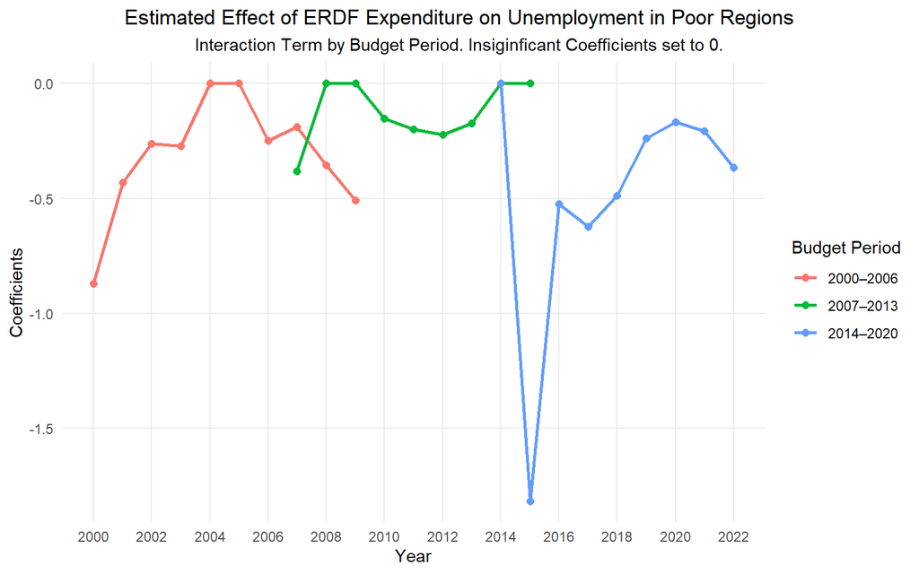

```r
coef_table <- imap_dfr(regression_ab, function(model, year) {
  tidy(model) |>
    mutate(year = year)
})

coef_table <- coef_table |>
  filter(str_detect(term, "expenditure") & str_detect(term, "poor")) |>
  mutate(estimate = if_else(p.value >= 0.1, 0, estimate)) |>
  mutate(term = case_when(
      str_detect(term, "2000-2006") ~ "2000–2006",
      str_detect(term, "2007-2013") ~ "2007–2013",
      str_detect(term, "2014-2020") ~ "2014–2020")) |>
  select(year, term, estimate)

p <- ggplot(coef_table, aes(x = as.numeric(year), y = estimate, color = term)) +
  geom_line(linewidth = 1) +
  geom_point(size = 2) +
  scale_x_continuous(breaks = seq(from = min(as.numeric(coef_table$year)),
                                  to = max(as.numeric(coef_table$year)),
                                  by = 2)) +
  labs(
    title = "Estimated Effect of ERDF Expenditure on Unemployment in Poor Regions",
    subtitle = "Interaction Term by Budget Period. Insiginficant Coefficients set to 0.",
    x = "Year",
    y = "Coefficients",
    color = "Budget Period"
  ) +
  theme_minimal() +
  theme(panel.grid.minor = element_blank(),
        plot.title = element_text(hjust = 0.5),
        plot.title.position = "plot",
        plot.subtitle = element_text(hjust = 0.5))

p
```

```r
# ggsave("expenditure_coefficients.png", plot = p, width = 8, height = 4, dpi = 500)
```